# Projeto Integrador - Modelagem

Andre Giusti Dambry, Flavio Barbosa Shirahige, Michel Maurice Conjaud Neto e Tiago Evangelista Pardo

2023-09-13

## 1. Etapa de Modelagem - Introdução

O objetivo dessa parte do Projeto Integrador é desenvolver um modelo previtivo para indicar se uma empresa irá falir em até dois anos a partir da avaliação em quatro classes de modelos:

- regressão logística
- regularização (modelos RIDGE e LASSO)
- floresta aleatória
- boosting

O pipeline de pré-processamento dos dados foi feito em Python e o seu resultado exportado para cvs para a modelagem em R. Nessa etapa de pré-processamento, foi criada a variável chamada will_close, que é a variável resposta desse processo de modelagem. Nela, o valor “1” significa que a empresa fechará em até 2 anos e ZERO (0) que a empresa não fechou nesse mesmo período de dois anos. O ano escolhido para o processo de modelagem, conforme os requisitos definidos nas isntruções desse projeto, foi o de 2012.

Além dos modelos listados acima, será utilizada uma abordagem de seleção de subconjuntos para as variáveis preditoras, stepwise.

### 1.1 Outliers

Conforme identificado na etapa de pré-processamento dos dados, o dataset utilizado possui um número significativo de outliers, uma vez que os dados se encontram concentrados em torno de empresas de volume de vendas menor. Para fins de análise, foram estimados modelos para as classes acima listadas com e sem esses outliers. No entanto, é importante ressaltar que esses outliers são parte relevante da população e podem conter informações sobre a mesma, podendo não ser observações que fogem do padrão típico de comportamento dessa população.

### 1.2 Critério de Avaliação dos Modelos de Classificação Estimados

Para avaliar o desempenho de cada um dos modelos de classificação estimados, será utilizada a área sob a curva ROC (AUC). A curva ROC (Receiver operating characteristic) é um gráfico que ilustra o desempenho de classificação correta de cada modelo à medida que o corte que delimita a classificação de um evento à partir das probalidades estimadas varia. A medida AUC é a área embaixo dessa curva calculada. Logo, ela mede a probabilidade de uma observação de evento ocorrer (no caso, se a empresa irá fechar) ter uma probabilidade maior do que uma observação do grupo de referência. Isto é, qual é o percentual de classificação correta do modelo em questão. Portante, um valor de AUC de um dado modelo igual 1 indica um desempenho de 100% na classificação e um valor de 0,5 significa que o modelo não é capaz de classificar de forma melhor do que uma escolha num processo aleatório.

É importante ressaltar que o corte para classificar se a empresa fechará ou não à partir das probabilidades estimadas pode variar a partir do próposito definido para esse processo de modelagem, algo que está fora do escopo desse projeto.

## 2. Modelagem

### 2.1 Análise dos Modelos

Agora, vamos construir os modelos para predizer a variável resposta will_close (se a empresa irá falir em até dois anos), ajustando os seus respectivos hiperparâmetros para obter o seu melhor desempenho, conforme abaixo:

- Regressão Logística
- Rigde: ajuste do lambda (penalização dos coeficientes) para encontrar o modelo ótimo
- LASSO: ajuste do lambda (penalização dos coeficientes) para encontrar o modelo ótimo
- Floresta Aleatória: serão estimados um modelo com 500 árvores e todas variáveis e outro em que testa-se o modelo de 1 a 500 árvores e de 2 a 24 variáveis por split
- Boosting: um modelo com 1000 árvores, taxa de aprendizado de 0,05 e 4 variáveis por split e um número de folds de 5
- Regressão logística com método stepewise para seleção de subconjuntos de varáveis

Além disso, também serão estimados os modelos descritos acima (exceto stepwise) sem os outliers. Foram considerados como outliers os valores que estão acima do valor Q3 + 1,5 * IQR, onde Q3 é o limite superior do terceiro quartil e IQR é o Intervalo Interquartil.

### 2.2 Importação, Análise Descritiva dos Dados e Tratamento das Informações Categóricas

O primeiro passo é importar os dados. Serão removidos os ID das empresas (comp_id), pois essas informações não serão utilizados na modelagem:

```r
csv_url <- "https://raw.githubusercontent.com/adambry/Atividade_Integradora_1T/main/df.csv"

dados <- read.csv(csv_url) %>%
  dplyr::select(-comp_id)
```

A próxima etapa é verificar se os dados foram migrados corretamente por meio de suas medidas:

```r
skim(dados)
```

Data summary

| Name | dados |
| --- | --- |
| Number of rows | 21020 |
| Number of columns | 25 |
| _______________________ |  |
| Column type frequency: |  |
| character | 2 |
| numeric | 23 |
| ________________________ |  |
| Group variables | None |

**Variable type: character**

| skim_variable | n_missing | complete_rate | min | max | empty | n_unique | whitespace |
| --- | --- | --- | --- | --- | --- | --- | --- |
| region_m | 0 | 1 | 4 | 7 | 0 | 3 | 0 |
| comp_size | 0 | 1 | 5 | 7 | 0 | 3 | 0 |

**Variable type: numeric**

| skim_variable | n_missing | complete_rate | mean | sd | p0 | p25 | p50 | p75 | p100 | hist |
| --- | --- | --- | --- | --- | --- | --- | --- | --- | --- | --- |
| amort | 0 | 1 | 16457.53 | 177013.40 | 0.00 | 0.00 | 488.89 | 2925.93 | 15921181.00 | ▇▁▁▁▁ |
| curr_assets | 0 | 1 | 195803.26 | 1851567.57 | 0.00 | 1851.85 | 7951.85 | 31114.81 | 91489976.00 | ▇▁▁▁▁ |
| curr_liab | 0 | 1 | 175197.66 | 2814470.30 | 0.00 | 1944.44 | 10824.07 | 40075.93 | 326405120.00 | ▇▁▁▁▁ |
| extra_exp | 0 | 1 | 1958.42 | 122386.28 | 0.00 | 0.00 | 0.00 | 0.00 | 17041718.00 | ▇▁▁▁▁ |
| extra_inc | 0 | 1 | 2891.72 | 124682.78 | 0.00 | 0.00 | 0.00 | 0.00 | 17092322.00 | ▇▁▁▁▁ |
| extra_profit_loss | 0 | 1 | 933.24 | 41587.37 | -2211577.75 | 0.00 | 0.00 | 0.00 | 3253703.75 | ▁▁▇▁▁ |
| fixed_assets | 0 | 1 | 281926.37 | 6258920.82 | 0.00 | 0.00 | 2333.33 | 28336.11 | 686351872.00 | ▇▁▁▁▁ |
| inc_bef_tax | 0 | 1 | 42641.93 | 666285.04 | 0.00 | 777.78 | 3614.81 | 12304.63 | 77992592.00 | ▇▁▁▁▁ |
| intang_assets | 0 | 1 | 13739.16 | 1108063.62 | 0.00 | 0.00 | 0.00 | 0.00 | 159444448.00 | ▇▁▁▁▁ |
| inventories | 0 | 1 | 58180.64 | 666621.47 | 0.00 | 0.00 | 238.89 | 4834.26 | 30963558.00 | ▇▁▁▁▁ |
| liq_assets | 0 | 1 | 37519.33 | 644416.18 | 0.00 | 288.89 | 1566.67 | 6831.48 | 79224256.00 | ▇▁▁▁▁ |
| material_exp | 0 | 1 | 317302.14 | 2687167.27 | 0.00 | 2388.89 | 18474.07 | 72131.48 | 96001928.00 | ▇▁▁▁▁ |
| personnel_exp | 0 | 1 | 84084.21 | 685357.47 | 0.00 | 285.19 | 7196.30 | 22879.63 | 45855412.00 | ▇▁▁▁▁ |
| profit_loss_year | 0 | 1 | 5321.60 | 255337.53 | -13973230.00 | -4812.04 | -74.07 | 1570.37 | 17001730.00 | ▁▁▇▁▁ |
| sales_x | 0 | 1 | 249996.63 | 780745.04 | 1003.70 | 16554.63 | 46892.59 | 146380.55 | 9997007.00 | ▇▁▁▁▁ |
| share_eq | 0 | 1 | 246716.31 | 5353042.89 | 0.00 | 3559.26 | 13051.85 | 42526.85 | 692925952.00 | ▇▁▁▁▁ |
| subscribed_cap | 0 | 1 | 76811.18 | 1501536.33 | 0.00 | 1851.85 | 1851.85 | 11111.11 | 159444448.00 | ▇▁▁▁▁ |
| tang_assets | 0 | 1 | 208485.12 | 3563323.32 | 0.00 | 0.00 | 1988.89 | 25476.85 | 451100736.00 | ▇▁▁▁▁ |
| urban_m | 0 | 1 | 2.08 | 0.85 | 1.00 | 1.00 | 2.00 | 3.00 | 3.00 | ▆▁▆▁▇ |
| labor_avg | 0 | 1 | 0.90 | 3.85 | 0.08 | 0.12 | 0.33 | 0.90 | 151.33 | ▇▁▁▁▁ |
| will_close | 0 | 1 | 0.03 | 0.16 | 0.00 | 0.00 | 0.00 | 0.00 | 1.00 | ▇▁▁▁▁ |
| curr_idx_liq | 0 | 1 | 624.18 | 16577.72 | -1366.67 | 0.27 | 1.11 | 3.59 | 1851851.88 | ▇▁▁▁▁ |
| comp_age | 0 | 1 | 8.49 | 7.01 | 0.00 | 2.00 | 7.00 | 14.00 | 63.00 | ▇▃▁▁▁ |

Apesar dos dados da variável “urban_m” terem sido convertidos para “object” (string) no pipeline de pré-processamento, essa variável foi armezada como numérica no arquivo csv. Assim, vamos convertê-la para fator, pois se trata de uma variável categórica.

```r
dados$urban_m <- factor(dados$urban_m)
skim(dados)
```

Data summary

| Name | dados |
| --- | --- |
| Number of rows | 21020 |
| Number of columns | 25 |
| _______________________ |  |
| Column type frequency: |  |
| character | 2 |
| factor | 1 |
| numeric | 22 |
| ________________________ |  |
| Group variables | None |

**Variable type: character**

| skim_variable | n_missing | complete_rate | min | max | empty | n_unique | whitespace |
| --- | --- | --- | --- | --- | --- | --- | --- |
| region_m | 0 | 1 | 4 | 7 | 0 | 3 | 0 |
| comp_size | 0 | 1 | 5 | 7 | 0 | 3 | 0 |

**Variable type: factor**

| skim_variable | n_missing | complete_rate | ordered | n_unique | top_counts |
| --- | --- | --- | --- | --- | --- |
| urban_m | 0 | 1 | FALSE | 3 | 3: 8465, 1: 6812, 2: 5743 |

**Variable type: numeric**

| skim_variable | n_missing | complete_rate | mean | sd | p0 | p25 | p50 | p75 | p100 | hist |
| --- | --- | --- | --- | --- | --- | --- | --- | --- | --- | --- |
| amort | 0 | 1 | 16457.53 | 177013.40 | 0.00 | 0.00 | 488.89 | 2925.93 | 15921181.00 | ▇▁▁▁▁ |
| curr_assets | 0 | 1 | 195803.26 | 1851567.57 | 0.00 | 1851.85 | 7951.85 | 31114.81 | 91489976.00 | ▇▁▁▁▁ |
| curr_liab | 0 | 1 | 175197.66 | 2814470.30 | 0.00 | 1944.44 | 10824.07 | 40075.93 | 326405120.00 | ▇▁▁▁▁ |
| extra_exp | 0 | 1 | 1958.42 | 122386.28 | 0.00 | 0.00 | 0.00 | 0.00 | 17041718.00 | ▇▁▁▁▁ |
| extra_inc | 0 | 1 | 2891.72 | 124682.78 | 0.00 | 0.00 | 0.00 | 0.00 | 17092322.00 | ▇▁▁▁▁ |
| extra_profit_loss | 0 | 1 | 933.24 | 41587.37 | -2211577.75 | 0.00 | 0.00 | 0.00 | 3253703.75 | ▁▁▇▁▁ |
| fixed_assets | 0 | 1 | 281926.37 | 6258920.82 | 0.00 | 0.00 | 2333.33 | 28336.11 | 686351872.00 | ▇▁▁▁▁ |
| inc_bef_tax | 0 | 1 | 42641.93 | 666285.04 | 0.00 | 777.78 | 3614.81 | 12304.63 | 77992592.00 | ▇▁▁▁▁ |
| intang_assets | 0 | 1 | 13739.16 | 1108063.62 | 0.00 | 0.00 | 0.00 | 0.00 | 159444448.00 | ▇▁▁▁▁ |
| inventories | 0 | 1 | 58180.64 | 666621.47 | 0.00 | 0.00 | 238.89 | 4834.26 | 30963558.00 | ▇▁▁▁▁ |
| liq_assets | 0 | 1 | 37519.33 | 644416.18 | 0.00 | 288.89 | 1566.67 | 6831.48 | 79224256.00 | ▇▁▁▁▁ |
| material_exp | 0 | 1 | 317302.14 | 2687167.27 | 0.00 | 2388.89 | 18474.07 | 72131.48 | 96001928.00 | ▇▁▁▁▁ |
| personnel_exp | 0 | 1 | 84084.21 | 685357.47 | 0.00 | 285.19 | 7196.30 | 22879.63 | 45855412.00 | ▇▁▁▁▁ |
| profit_loss_year | 0 | 1 | 5321.60 | 255337.53 | -13973230.00 | -4812.04 | -74.07 | 1570.37 | 17001730.00 | ▁▁▇▁▁ |
| sales_x | 0 | 1 | 249996.63 | 780745.04 | 1003.70 | 16554.63 | 46892.59 | 146380.55 | 9997007.00 | ▇▁▁▁▁ |
| share_eq | 0 | 1 | 246716.31 | 5353042.89 | 0.00 | 3559.26 | 13051.85 | 42526.85 | 692925952.00 | ▇▁▁▁▁ |
| subscribed_cap | 0 | 1 | 76811.18 | 1501536.33 | 0.00 | 1851.85 | 1851.85 | 11111.11 | 159444448.00 | ▇▁▁▁▁ |
| tang_assets | 0 | 1 | 208485.12 | 3563323.32 | 0.00 | 0.00 | 1988.89 | 25476.85 | 451100736.00 | ▇▁▁▁▁ |
| labor_avg | 0 | 1 | 0.90 | 3.85 | 0.08 | 0.12 | 0.33 | 0.90 | 151.33 | ▇▁▁▁▁ |
| will_close | 0 | 1 | 0.03 | 0.16 | 0.00 | 0.00 | 0.00 | 0.00 | 1.00 | ▇▁▁▁▁ |
| curr_idx_liq | 0 | 1 | 624.18 | 16577.72 | -1366.67 | 0.27 | 1.11 | 3.59 | 1851851.88 | ▇▁▁▁▁ |
| comp_age | 0 | 1 | 8.49 | 7.01 | 0.00 | 2.00 | 7.00 | 14.00 | 63.00 | ▇▃▁▁▁ |

Para as variáveis categóricas, vamos transformá-las em fator para a modelagem no R por ser um pré-requisito das funções dessa linguagem:

```r
dados <- dados %>%
  mutate_if(is.character, ~as.factor(.x))
```

### 2.3 Modelos com Outliers

Para o processo de modelagem, a primeira etapa é criar os datasets de treinamento e teste, onde 80% do dataset será de treinamento:

```r
set.seed(321)

idx <- sample(nrow(dados), size = .80 * nrow(dados), replace = FALSE)

treino <- dados[idx,]
teste  <- dados[-idx,]
```

#### 2.3.1 Regressão Logística

O primeiro modelo a ser estimado é o de regressão logística:

```r
log <- suppressWarnings({glm(will_close ~ ., data = treino, family = 'binomial')})
summary(log)
```

```
##
## Call:
## glm(formula = will_close ~ ., family = "binomial", data = treino)
##
## Coefficients:
##                     Estimate Std. Error z value Pr(>|z|)
## (Intercept)       -4.455e+00  1.720e-01 -25.897  < 2e-16 ***
## amort              6.644e-08  1.053e-06   0.063   0.9497
## curr_assets       -4.514e-09  1.892e-07  -0.024   0.9810
## curr_liab         -6.261e-08  1.170e-07  -0.535   0.5925
## extra_exp         -2.871e-04  2.767e-04  -1.038   0.2995
## extra_inc          2.845e-04  2.767e-04   1.028   0.3038
## extra_profit_loss -2.837e-04  2.766e-04  -1.026   0.3051
## fixed_assets      -9.293e-08  2.496e-07  -0.372   0.7097
## inc_bef_tax       -6.635e-07  6.592e-07  -1.007   0.3141
## intang_assets      7.881e-08  2.677e-07   0.294   0.7685
## inventories        3.161e-08  2.593e-07   0.122   0.9030
## liq_assets         1.818e-07  1.971e-07   0.922   0.3565
## material_exp       2.594e-08  5.644e-08   0.459   0.6459
## personnel_exp      2.821e-08  2.802e-07   0.101   0.9198
## profit_loss_year   4.255e-07  6.491e-07   0.656   0.5121
## sales_x            6.196e-08  8.593e-08   0.721   0.4709
## share_eq          -5.474e-09  9.935e-08  -0.055   0.9561
## subscribed_cap     2.216e-09  1.075e-07   0.021   0.9836
## tang_assets        8.651e-08  2.554e-07   0.339   0.7348
## urban_m2          -2.353e-03  1.458e-01  -0.016   0.9871
## urban_m3           1.503e-01  1.279e-01   1.175   0.2400
## region_mEast      -3.045e-01  1.376e-01  -2.213   0.0269 *
## region_mWest      -2.057e-01  1.562e-01  -1.317   0.1878
## labor_avg         -5.963e-03  3.914e-02  -0.152   0.8789
## curr_idx_liq      -3.737e-06  9.867e-06  -0.379   0.7049
## comp_age           4.508e-03  6.949e-03   0.649   0.5165
## comp_sizeMédia     2.423e-01  2.147e-01   1.128   0.2592
## comp_sizePequena   1.246e+00  1.539e-01   8.093 5.81e-16 ***
## ---
## Signif. codes:  0 '***' 0.001 '**' 0.01 '*' 0.05 '.' 0.1 ' ' 1
##
## (Dispersion parameter for binomial family taken to be 1)
##
##     Null deviance: 4052.8  on 16815  degrees of freedom
## Residual deviance: 3923.3  on 16788  degrees of freedom
## AIC: 3979.3
##
## Number of Fisher Scoring iterations: 10
```

Agora, vamos aplicar o modelo de previsão nos dados de teste para estimar as probabilidades:

```r
prob_log <- predict(log, newdata = teste, type = "response")
```

E armazenar em um tibble os resultados das probabilidades obtidas pela regressão logística e a respectiva classe observada:

```r
desempenho <- tibble(prob = prob_log,
                   classes = teste$will_close,
                   metodo = "logística")
```

Abaixo, foi plotado o gráfico com a importância de cada variável para esse modelo:

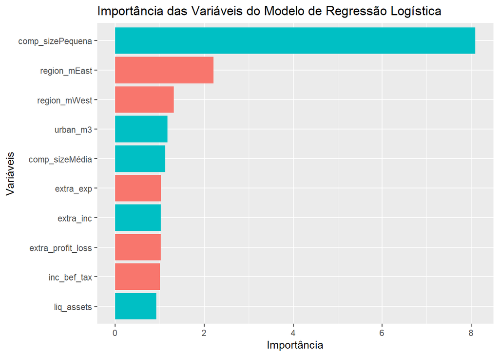

```r
vip(log, mapping = aes(fill = Sign)) + labs(title = "Importância das Variáveis do Modelo de Regressão Logística", x = "Variáveis", y = "Importância")
```

#### 2.3.2 Modelo Ridge

O próximo modelo a ser estimado é o Ridge. Primeiro, deverão ser preparadados os datasets de treinamento e teste para aplicação da função do pacote glmnet.

```r
X_treino <- model.matrix(will_close ~ ., dados)[idx,-1]
y_treino <- dados$will_close[idx]

X_teste <- model.matrix(will_close ~ ., dados)[-idx,-1]
y_teste <- dados$will_close[-idx]
```

Abaixo, foi criado o modelo Ridge e plotando o gráfico com os lambdas variando até 500:

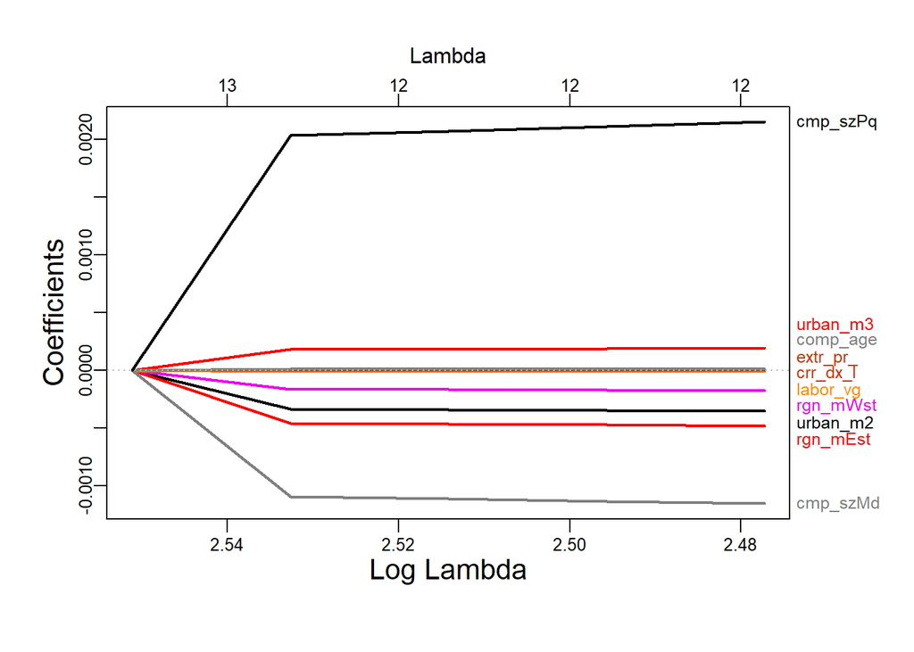

```r
ridge <- glmnet(X_treino, y_treino,  alpha = 0, nlambda = 500, family = "binomial")
plot_glmnet(ridge, lwd = 2, cex.lab = 1.3)
```

A seguir, vamos fazer a validação cruzada do modelo:

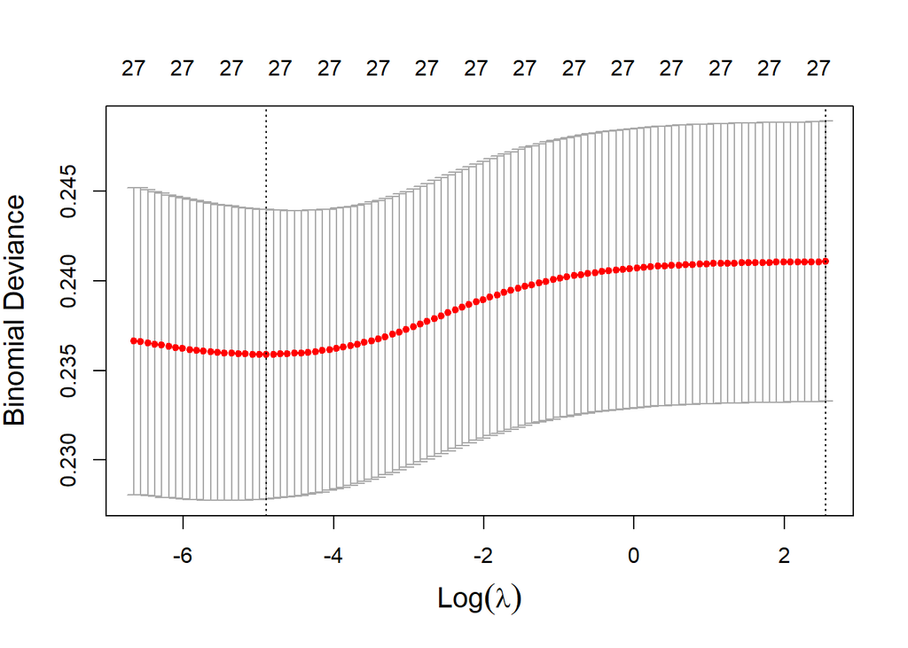

```r
cv_ridge <- cv.glmnet(X_treino, y_treino, alpha = 0, family = "binomial")
plot(cv_ridge, cex.lab = 1.3)
```

Vamos aplicar o modelo de previsão com base no melhor lambda (menor erro), estimando as probabilidades a partir da base de teste:

```r
prob_ridge <- predict(ridge, newx = X_teste, s = cv_ridge$lambda.min, type = "response")
```

E armazenar em um tibble os resultados das probabilidades obtidas pelo modelo Ridge e a respectiva classe observada:

```r
desempenho <- desempenho %>%
  bind_rows(tibble(prob = as.numeric(prob_ridge),
                   classes = y_teste,
                   metodo = "ridge"))
```

Abaixo, plotamos o gráfico com a importância de cada variável para esse modelo Rigde:

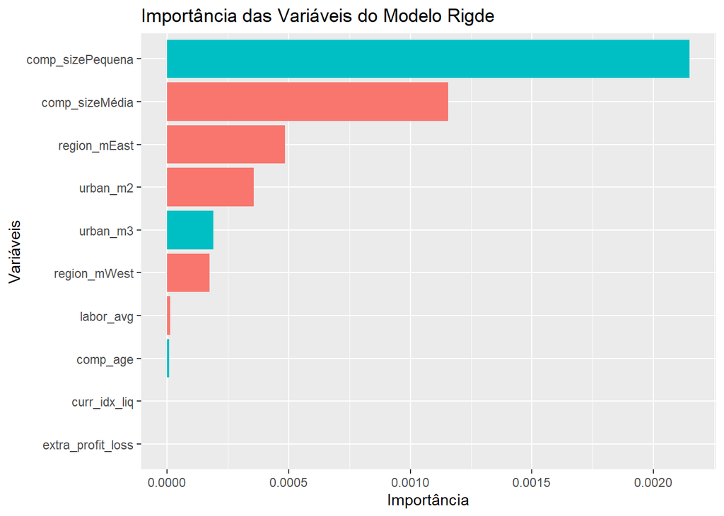

```r
vip(ridge, mapping = aes(fill = Sign)) + labs(title = "Importância das Variáveis do Modelo Rigde", x = "Variáveis", y = "Importância")
```

#### 2.3.3 Regressão LASSO

O modelo seguinte a ser criado é o LASSO. Assim como no modelo Ridge, foi criado o modelo LASSO e plotado o gráfico com os lambdas variando até 500:

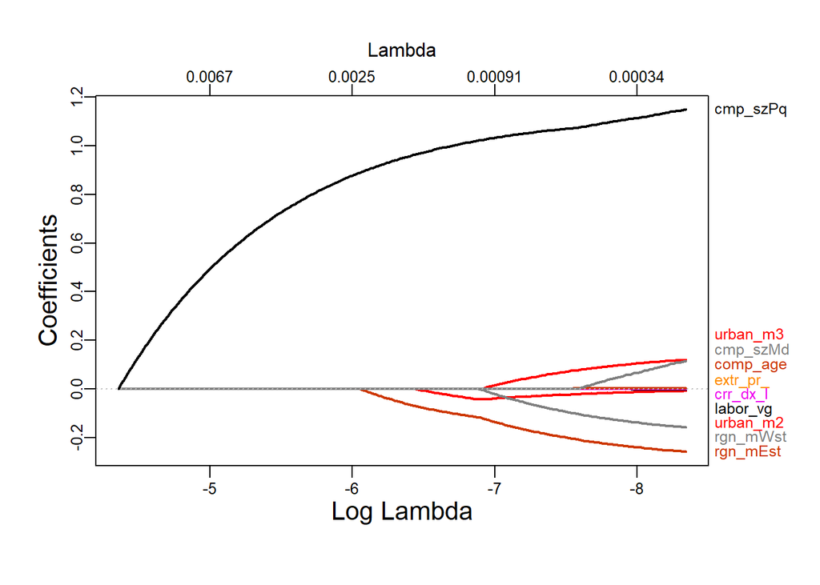

```r
lasso <- glmnet(X_treino, y_treino,  alpha = 1, nlambda = 500, family = "binomial")
plot_glmnet(lasso, lwd = 2, cex.lab = 1.3)
```

O próximo passo é fazer a validação cruzada do modelo:

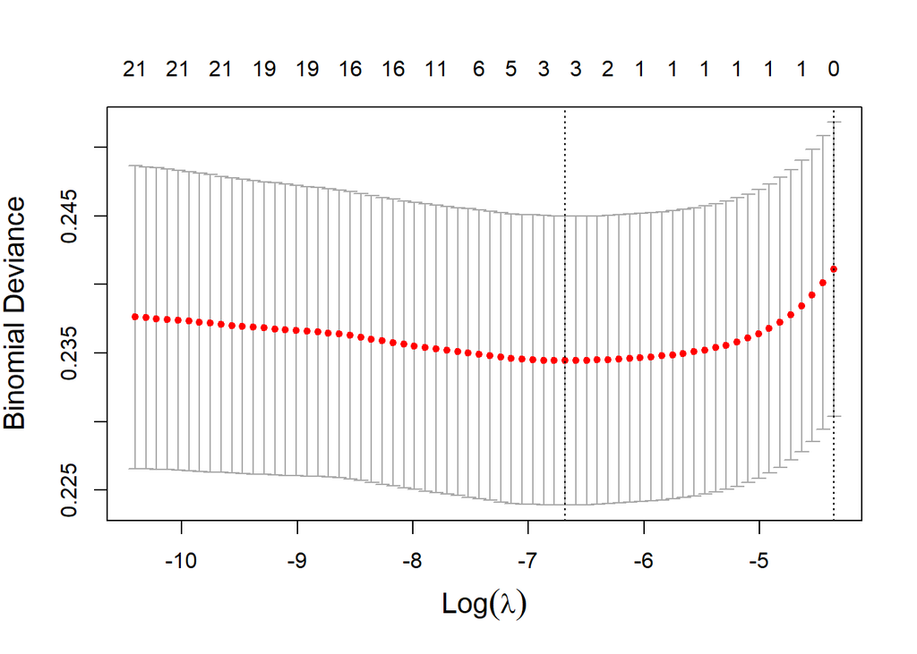

```r
cv_lasso <- cv.glmnet(X_treino, y_treino, alpha = 1, family = "binomial")
plot(cv_lasso, cex.lab = 1.3)
```

Agora, será aplicado o modelo de previsão com base no melhor lambda (menor erro), estimando as probabilidades a partir da base de teste:

```r
prob_lasso <- predict(lasso, newx = X_teste, s = cv_lasso$lambda.min, type = "response")
```

E armazenado em um tibble os resultados das probabilidades obtidas pelo modelo Lasso e a respectiva classe observada:

```r
desempenho <- desempenho %>%
  bind_rows(tibble(prob = as.numeric(prob_lasso),
                   classes = y_teste,
                   metodo = "lasso"))
```

Abaixo, foi plotado o gráfico com a importância de cada variável para esse modelo:

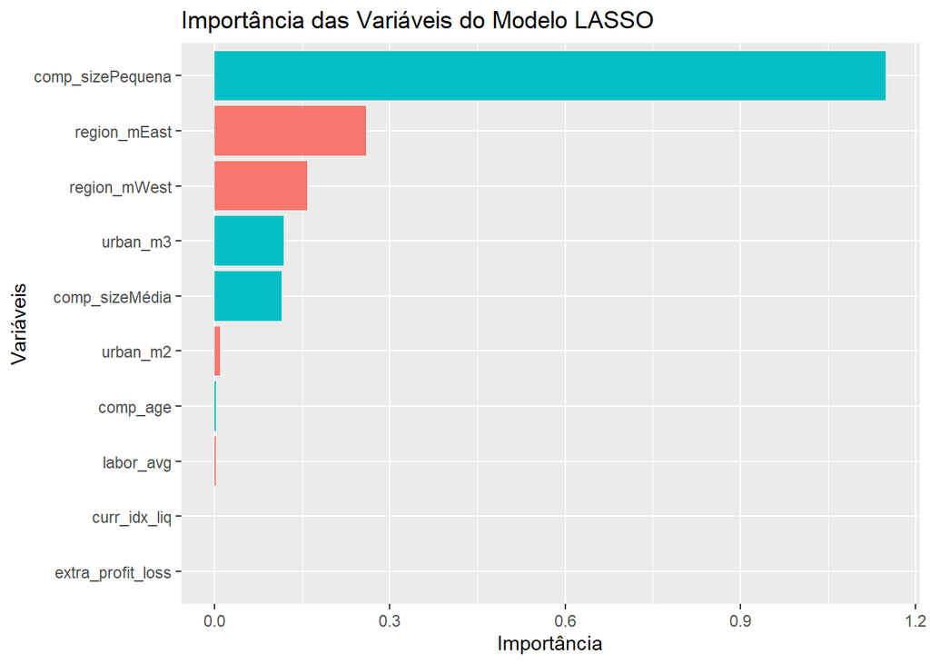

```r
vip(lasso, mapping = aes(fill = Sign)) + labs(title = "Importância das Variáveis do Modelo LASSO", x = "Variáveis", y = "Importância")
```

#### 2.3.4 Floresta Aleatória

O próximo modelo que será criado e testado é o de floresta aleatória com 500 árvores e com todas as variáveis:

```r
rf <- ranger(will_close ~ ., probability = TRUE, data = treino)
```

Para essa floresta aleatória com 500 árvores e com todas as variáveis, vamos fazer a previsão a partir dos dados de teste:

```r
prob_rf <- predict(rf, teste)$predictions[,2]
```

E armazenando em um tibble os resultados das probabilidades obtidas pelo modelo de floresta aleatória e a respectiva classe observada:

```r
desempenho <- desempenho %>%
  bind_rows(tibble(prob = prob_rf,
                   classes = teste$will_close,
                   metodo = "floresta aleatória"))
```

Abaixo, plotamos o gráfico com a importância de cada variável para esse modelo de floresta aleatória:

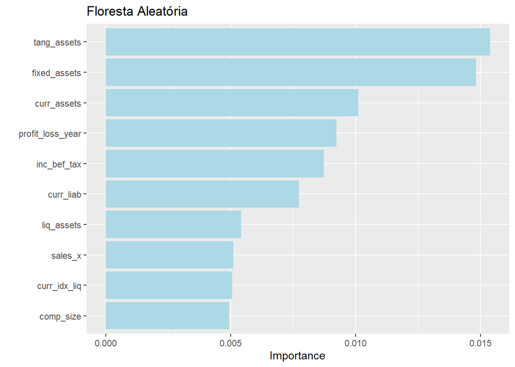

```r
vip(ranger(will_close ~ ., probability = TRUE, importance = "permutation", data = dados), aesthetics = list(fill = "lightblue")) + labs(title = "Floresta Aleatória")
```

Agora, vamos iterar para testar o número de árvores de 1 a 500, bem como o número de variáveis por split, plotar o resultado dessa iteração:

```r
result_arvores <- crossing(mtry = c(2, 4, 8, 12, 16, 20, 24), #número de variáveis por split a ser testados
                       n_arvores = c(1:10, seq(10, 500, 10)))
itera <- function(mtry, n_arvores) {
  rf_itera <- ranger(will_close ~ ., probability = TRUE, num.trees = n_arvores, mtry = mtry, data = treino)
  return(rf_itera$prediction.error)
}
result_arvores <- result_arvores %>%
  mutate(erro = map2_dbl(mtry, n_arvores, itera))
head(result_arvores)
```

```
## # A tibble: 6 × 3
##    mtry n_arvores   erro
##   <dbl>     <dbl>  <dbl>
## 1     2         1 0.0397
## 2     2         2 0.0370
## 3     2         3 0.0376
## 4     2         4 0.0360
## 5     2         5 0.0354
## 6     2         6 0.0338
```

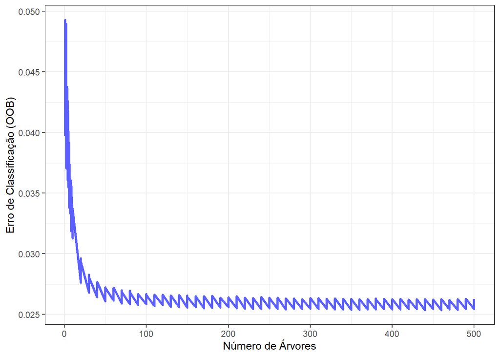

```r
result_arvores %>% ggplot(aes(n_arvores, erro)) +
 geom_line(color = "#5B5FFF", size = 1.2) +
 labs(x = "Número de Árvores", y = "Erro de Classificação (OOB)") +
 theme_bw()
```

A partir da iteração acima, vamos obter os dados da floresta ótima (número de árvores e número de variáveis por split) com o menor erro:

```r
floresta_otima <- result_arvores %>% as_tibble() %>% filter(erro== min(erro))#Obtendo dados da floresta ótima
mtry_otimo <- floresta_otima$mtry #numero de arvores para floresta otima
n_arvores_otimo <- floresta_otima$n_arvores # variaveis por split
```

E criar o modelo de floresta aleatória ótima:

```r
rf_otima <- ranger(will_close ~ ., probability = TRUE, num.trees = n_arvores_otimo,
                   mtry = mtry_otimo, data = treino)
```

Para essa floresta aleatória ótima, vamos fazer a previsão a partir dos dados de teste:

```r
prob_rf_otima <- predict(rf_otima, teste)$predictions[,2]
```

```r
desempenho <- desempenho %>%
  bind_rows(tibble(prob = prob_rf_otima,
                   classes = teste$will_close,
                   metodo = "floresta aleatória ótima"))
```

Abaixo, plotamos o gráfico com a importância de cada variável para esse modelo de floresta aleatória otimizada:

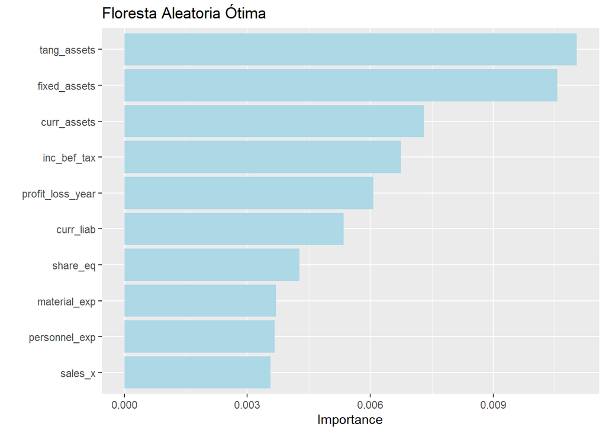

```r
vip(ranger(will_close ~ ., probability = TRUE, importance = "permutation", num.trees = n_arvores_otimo, mtry = mtry_otimo, data = treino),
    aesthetics = list(fill = "lightblue")) + labs(title = "Floresta Aleatoria Ótima")
```

#### 2.3.5 Boosting

O último modelo que será criado e testado nesse ciclo de modelagem é o Boosting com 1000 árvores, taxa de aprendizagem de 0,05, 4 variáveis por split e um número de folds de 5:

```r
(fit_bst <- gbm(will_close ~ ., distribution = "bernoulli", n.trees = 1000,
                interaction.depth = 4, shrinkage = 0.05, data = treino))
```

```
## gbm(formula = will_close ~ ., distribution = "bernoulli", data = treino,
##     n.trees = 1000, interaction.depth = 4, shrinkage = 0.05)
## A gradient boosted model with bernoulli loss function.
## 1000 iterations were performed.
## There were 24 predictors of which 24 had non-zero influence.
```

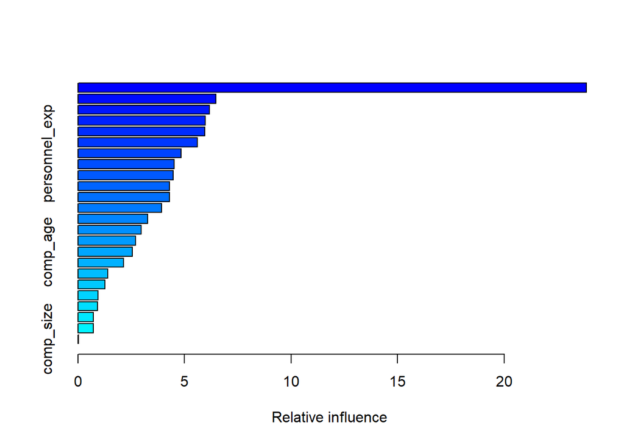

```
##                                 var     rel.inf
## sales_x                     sales_x 23.86283574
## liq_assets               liq_assets  6.47155139
## inc_bef_tax             inc_bef_tax  6.16666798
## share_eq                   share_eq  5.98205126
## curr_idx_liq           curr_idx_liq  5.96135396
## curr_liab                 curr_liab  5.60775298
## personnel_exp         personnel_exp  4.83421457
## profit_loss_year   profit_loss_year  4.50665286
## inventories             inventories  4.47173273
## curr_assets             curr_assets  4.28830233
## material_exp           material_exp  4.28782116
## labor_avg                 labor_avg  3.91605317
## subscribed_cap       subscribed_cap  3.27317937
## amort                         amort  2.96869884
## fixed_assets           fixed_assets  2.71378438
## comp_age                   comp_age  2.55645128
## tang_assets             tang_assets  2.14571757
## urban_m                     urban_m  1.39524948
## extra_profit_loss extra_profit_loss  1.25858786
## intang_assets         intang_assets  0.94182126
## extra_inc                 extra_inc  0.91228472
## extra_exp                 extra_exp  0.72792909
## region_m                   region_m  0.72029940
## comp_size                 comp_size  0.02900662
```

```r
summary(fit_bst)
```

O passo seguinte é fazer a validação cruzadas do modelo para obter o número de árvores ótimo:

```r
fit_cv <- gbm(will_close ~ ., data = treino, cv.folds = 5, n.trees = 1000,
              interaction.depth = 4, distribution = "bernoulli", shrinkage = 0.05)

num_arv_boost <- gbm.perf(fit_cv, method = "cv") #obtendo a árvore ótima
```

[figure not shown]

Aplicando o modelo de previsão com base na melhor quantidade de árvores (menor erro) e estimando as probabilidades a partir da base de teste, temos:

```r
prob_gbm <- predict(fit_cv, teste, n.trees = num_arv_boost, type = "response")
```

```r
desempenho <- desempenho %>%
  bind_rows(tibble(prob = prob_gbm,
                   classes = teste$will_close,
                   metodo = "boosting"))
```

#### 2.3.6 Regressão logística com stepwise

Após estimar os cincos modelos acima, vamos verificar se a redução de variáveis para o modelo de regressão logística melhora o desempenho deste. Para tal, será utilizado o método stepwise. Assim, vamos selecionar primeiro as variáveis a serem utilizadas por meio do método stepwise colocando como direção “backward”, uma vez que foi a que melhor desempenhou em relação a “both” e “forward” em testes anteriorer:

```r
modelo_stepAIC <- stepAIC(log, direction = "backward")
```

```
## Start:  AIC=3979.25
## will_close ~ amort + curr_assets + curr_liab + extra_exp + extra_inc +
##     extra_profit_loss + fixed_assets + inc_bef_tax + intang_assets +
##     inventories + liq_assets + material_exp + personnel_exp +
##     profit_loss_year + sales_x + share_eq + subscribed_cap +
##     tang_assets + urban_m + region_m + labor_avg + curr_idx_liq +
##     comp_age + comp_size
```

[output not shown]

```
##                     Df Deviance    AIC
## - subscribed_cap     1   3923.3 3977.3
## - curr_assets        1   3923.3 3977.3
## - share_eq           1   3923.3 3977.3
## - amort              1   3923.3 3977.3
## - personnel_exp      1   3923.3 3977.3
## - inventories        1   3923.3 3977.3
## - labor_avg          1   3923.3 3977.3
## - intang_assets      1   3923.3 3977.3
## - tang_assets        1   3923.4 3977.4
## - urban_m            2   3925.4 3977.4
## - fixed_assets       1   3923.4 3977.4
## - material_exp       1   3923.5 3977.5
## - curr_idx_liq       1   3923.5 3977.5
## - curr_liab          1   3923.6 3977.6
## - comp_age           1   3923.7 3977.7
## - sales_x            1   3923.7 3977.7
## - profit_loss_year   1   3923.8 3977.8
## - extra_profit_loss  1   3924.0 3978.0
## - extra_inc          1   3924.0 3978.0
## - extra_exp          1   3924.0 3978.0
## - liq_assets         1   3924.3 3978.3
## - inc_bef_tax        1   3924.6 3978.6
## <none>                   3923.3 3979.3
## - region_m           2   3928.5 3980.5
## - comp_size          2   4026.2 4078.2
```

```
##
## Step:  AIC=3977.25
## will_close ~ amort + curr_assets + curr_liab + extra_exp + extra_inc +
##     extra_profit_loss + fixed_assets + inc_bef_tax + intang_assets +
##     inventories + liq_assets + material_exp + personnel_exp +
##     profit_loss_year + sales_x + share_eq + tang_assets + urban_m +
##     region_m + labor_avg + curr_idx_liq + comp_age + comp_size
```

[output not shown]

```
##                     Df Deviance    AIC
## - curr_assets        1   3923.3 3975.3
## - share_eq           1   3923.3 3975.3
## - amort              1   3923.3 3975.3
## - personnel_exp      1   3923.3 3975.3
## - inventories        1   3923.3 3975.3
## - labor_avg          1   3923.3 3975.3
## - intang_assets      1   3923.3 3975.3
## - tang_assets        1   3923.4 3975.4
## - urban_m            2   3925.4 3975.4
## - fixed_assets       1   3923.4 3975.4
## - material_exp       1   3923.5 3975.5
## - curr_idx_liq       1   3923.5 3975.5
## - curr_liab          1   3923.6 3975.6
## - comp_age           1   3923.7 3975.7
## - sales_x            1   3923.7 3975.7
## - profit_loss_year   1   3923.8 3975.8
## - extra_profit_loss  1   3924.0 3976.0
## - extra_inc          1   3924.0 3976.0
## - extra_exp          1   3924.0 3976.0
## - liq_assets         1   3924.3 3976.3
## - inc_bef_tax        1   3924.6 3976.6
## <none>                   3923.3 3977.3
## - region_m           2   3928.5 3978.5
## - comp_size          2   4026.2 4076.2
```

```
##
## Step:  AIC=3975.25
## will_close ~ amort + curr_liab + extra_exp + extra_inc + extra_profit_loss +
##     fixed_assets + inc_bef_tax + intang_assets + inventories +
##     liq_assets + material_exp + personnel_exp + profit_loss_year +
##     sales_x + share_eq + tang_assets + urban_m + region_m + labor_avg +
##     curr_idx_liq + comp_age + comp_size
```

[output not shown]

```
##                     Df Deviance    AIC
## - share_eq           1   3923.3 3973.3
## - amort              1   3923.3 3973.3
## - personnel_exp      1   3923.3 3973.3
## - inventories        1   3923.3 3973.3
## - labor_avg          1   3923.3 3973.3
## - intang_assets      1   3923.3 3973.3
## - tang_assets        1   3923.4 3973.4
## - urban_m            2   3925.4 3973.4
## - fixed_assets       1   3923.4 3973.4
## - material_exp       1   3923.5 3973.5
## - curr_idx_liq       1   3923.5 3973.5
## - comp_age           1   3923.7 3973.7
## - curr_liab          1   3923.7 3973.7
## - sales_x            1   3923.7 3973.7
## - profit_loss_year   1   3923.8 3973.8
## - extra_profit_loss  1   3924.0 3974.0
## - extra_inc          1   3924.0 3974.0
## - extra_exp          1   3924.0 3974.0
## - inc_bef_tax        1   3924.6 3974.6
## - liq_assets         1   3924.7 3974.7
## <none>                   3923.3 3975.3
## - region_m           2   3928.5 3976.5
## - comp_size          2   4026.2 4074.2
```

```
##
## Step:  AIC=3973.26
## will_close ~ amort + curr_liab + extra_exp + extra_inc + extra_profit_loss +
##     fixed_assets + inc_bef_tax + intang_assets + inventories +
##     liq_assets + material_exp + personnel_exp + profit_loss_year +
##     sales_x + tang_assets + urban_m + region_m + labor_avg +
##     curr_idx_liq + comp_age + comp_size
```

[output not shown]

```
##                     Df Deviance    AIC
## - amort              1   3923.3 3971.3
## - personnel_exp      1   3923.3 3971.3
## - inventories        1   3923.3 3971.3
## - labor_avg          1   3923.3 3971.3
## - intang_assets      1   3923.3 3971.3
## - urban_m            2   3925.4 3971.4
## - tang_assets        1   3923.4 3971.4
## - material_exp       1   3923.5 3971.5
## - curr_idx_liq       1   3923.5 3971.5
## - fixed_assets       1   3923.5 3971.5
## - comp_age           1   3923.7 3971.7
## - sales_x            1   3923.7 3971.7
## - curr_liab          1   3923.8 3971.8
## - profit_loss_year   1   3923.8 3971.8
## - extra_profit_loss  1   3924.0 3972.0
## - extra_inc          1   3924.0 3972.0
## - extra_exp          1   3924.0 3972.0
## - liq_assets         1   3924.7 3972.7
## - inc_bef_tax        1   3924.7 3972.7
## <none>                   3923.3 3973.3
## - region_m           2   3928.5 3974.5
## - comp_size          2   4026.3 4072.3
```

```
##
## Step:  AIC=3971.26
## will_close ~ curr_liab + extra_exp + extra_inc + extra_profit_loss +
##     fixed_assets + inc_bef_tax + intang_assets + inventories +
##     liq_assets + material_exp + personnel_exp + profit_loss_year +
##     sales_x + tang_assets + urban_m + region_m + labor_avg +
##     curr_idx_liq + comp_age + comp_size
```

[output not shown]

```
##                     Df Deviance    AIC
## - personnel_exp      1   3923.3 3969.3
## - inventories        1   3923.3 3969.3
## - labor_avg          1   3923.3 3969.3
## - intang_assets      1   3923.3 3969.3
## - urban_m            2   3925.4 3969.4
## - tang_assets        1   3923.5 3969.5
## - material_exp       1   3923.5 3969.5
## - curr_idx_liq       1   3923.5 3969.5
## - fixed_assets       1   3923.5 3969.5
## - comp_age           1   3923.7 3969.7
## - sales_x            1   3923.7 3969.7
## - curr_liab          1   3923.8 3969.8
## - profit_loss_year   1   3923.8 3969.8
## - extra_profit_loss  1   3924.0 3970.0
## - extra_inc          1   3924.0 3970.0
## - extra_exp          1   3924.0 3970.0
## - inc_bef_tax        1   3924.8 3970.8
## - liq_assets         1   3924.8 3970.8
## <none>                   3923.3 3971.3
## - region_m           2   3928.5 3972.5
## - comp_size          2   4026.3 4070.3
```

```
##
## Step:  AIC=3969.27
## will_close ~ curr_liab + extra_exp + extra_inc + extra_profit_loss +
##     fixed_assets + inc_bef_tax + intang_assets + inventories +
##     liq_assets + material_exp + profit_loss_year + sales_x +
##     tang_assets + urban_m + region_m + labor_avg + curr_idx_liq +
##     comp_age + comp_size
```

[output not shown]

```
##                     Df Deviance    AIC
## - labor_avg          1   3923.3 3967.3
## - inventories        1   3923.3 3967.3
## - intang_assets      1   3923.3 3967.3
## - urban_m            2   3925.4 3967.4
## - tang_assets        1   3923.5 3967.5
## - curr_idx_liq       1   3923.5 3967.5
## - material_exp       1   3923.6 3967.6
## - fixed_assets       1   3923.6 3967.6
## - comp_age           1   3923.7 3967.7
## - sales_x            1   3923.7 3967.7
## - curr_liab          1   3923.8 3967.8
## - profit_loss_year   1   3923.9 3967.9
## - extra_profit_loss  1   3924.0 3968.0
## - extra_inc          1   3924.0 3968.0
## - extra_exp          1   3924.0 3968.0
## - inc_bef_tax        1   3924.8 3968.8
## - liq_assets         1   3924.8 3968.8
## <none>                   3923.3 3969.3
## - region_m           2   3928.5 3970.5
## - comp_size          2   4026.3 4068.3
```

```
##
## Step:  AIC=3967.29
## will_close ~ curr_liab + extra_exp + extra_inc + extra_profit_loss +
##     fixed_assets + inc_bef_tax + intang_assets + inventories +
##     liq_assets + material_exp + profit_loss_year + sales_x +
##     tang_assets + urban_m + region_m + curr_idx_liq + comp_age +
##     comp_size
```

[output not shown]

```
##                     Df Deviance    AIC
## - inventories        1   3923.3 3965.3
## - intang_assets      1   3923.4 3965.4
## - urban_m            2   3925.4 3965.4
## - tang_assets        1   3923.5 3965.5
## - curr_idx_liq       1   3923.5 3965.5
## - material_exp       1   3923.6 3965.6
## - fixed_assets       1   3923.6 3965.6
## - comp_age           1   3923.7 3965.7
## - sales_x            1   3923.8 3965.8
## - curr_liab          1   3923.8 3965.8
## - profit_loss_year   1   3923.9 3965.9
## - extra_profit_loss  1   3924.0 3966.0
## - extra_inc          1   3924.0 3966.0
## - extra_exp          1   3924.0 3966.0
## - liq_assets         1   3924.9 3966.9
## - inc_bef_tax        1   3924.9 3966.9
## <none>                   3923.3 3967.3
## - region_m           2   3928.5 3968.5
## - comp_size          2   4026.3 4066.3
```

```
##
## Step:  AIC=3965.3
## will_close ~ curr_liab + extra_exp + extra_inc + extra_profit_loss +
##     fixed_assets + inc_bef_tax + intang_assets + liq_assets +
##     material_exp + profit_loss_year + sales_x + tang_assets +
##     urban_m + region_m + curr_idx_liq + comp_age + comp_size
```

[output not shown]

```
##                     Df Deviance    AIC
## - intang_assets      1   3923.4 3963.4
## - urban_m            2   3925.5 3963.5
## - tang_assets        1   3923.5 3963.5
## - curr_idx_liq       1   3923.6 3963.6
## - fixed_assets       1   3923.6 3963.6
## - comp_age           1   3923.7 3963.7
## - sales_x            1   3923.8 3963.8
## - curr_liab          1   3923.8 3963.8
## - profit_loss_year   1   3923.9 3963.9
## - extra_profit_loss  1   3924.0 3964.0
## - extra_inc          1   3924.0 3964.0
## - extra_exp          1   3924.0 3964.0
## - material_exp       1   3924.1 3964.1
## - liq_assets         1   3924.9 3964.9
## - inc_bef_tax        1   3924.9 3964.9
## <none>                   3923.3 3965.3
## - region_m           2   3928.6 3966.6
## - comp_size          2   4026.4 4064.4
```

```
##
## Step:  AIC=3963.37
## will_close ~ curr_liab + extra_exp + extra_inc + extra_profit_loss +
##     fixed_assets + inc_bef_tax + liq_assets + material_exp +
##     profit_loss_year + sales_x + tang_assets + urban_m + region_m +
##     curr_idx_liq + comp_age + comp_size
```

[output not shown]

```
##                     Df Deviance    AIC
## - tang_assets        1   3923.5 3961.5
## - urban_m            2   3925.5 3961.5
## - curr_idx_liq       1   3923.6 3961.6
## - fixed_assets       1   3923.7 3961.7
## - comp_age           1   3923.8 3961.8
## - sales_x            1   3923.8 3961.8
## - profit_loss_year   1   3923.9 3961.9
## - curr_liab          1   3924.0 3962.0
## - extra_profit_loss  1   3924.1 3962.1
## - extra_inc          1   3924.1 3962.1
## - extra_exp          1   3924.1 3962.1
## - material_exp       1   3924.2 3962.2
## - liq_assets         1   3924.9 3962.9
## - inc_bef_tax        1   3924.9 3962.9
## <none>                   3923.4 3963.4
## - region_m           2   3928.6 3964.6
## - comp_size          2   4026.4 4062.4
```

```
##
## Step:  AIC=3961.53
## will_close ~ curr_liab + extra_exp + extra_inc + extra_profit_loss +
##     fixed_assets + inc_bef_tax + liq_assets + material_exp +
##     profit_loss_year + sales_x + urban_m + region_m + curr_idx_liq +
##     comp_age + comp_size
```

```
##                     Df Deviance    AIC
## - fixed_assets       1   3923.7 3959.7
## - urban_m            2   3925.7 3959.7
## - curr_idx_liq       1   3923.8 3959.8
## - comp_age           1   3923.9 3959.9
## - sales_x            1   3924.0 3960.0
## - profit_loss_year   1   3924.0 3960.0
## - extra_profit_loss  1   3924.2 3960.2
## - extra_inc          1   3924.3 3960.3
## - extra_exp          1   3924.3 3960.3
## - curr_liab          1   3924.4 3960.4
## - material_exp       1   3924.6 3960.6
## - liq_assets         1   3924.9 3960.9
## - inc_bef_tax        1   3924.9 3960.9
## <none>                   3923.5 3961.5
## - region_m           2   3928.8 3962.8
## - comp_size          2   4026.4 4060.4
```

```
##
## Step:  AIC=3959.67
## will_close ~ curr_liab + extra_exp + extra_inc + extra_profit_loss +
##     inc_bef_tax + liq_assets + material_exp + profit_loss_year +
##     sales_x + urban_m + region_m + curr_idx_liq + comp_age +
##     comp_size
```

```
##                     Df Deviance    AIC
## - urban_m            2   3925.8 3957.8
## - curr_idx_liq       1   3923.9 3957.9
## - comp_age           1   3924.1 3958.1
## - sales_x            1   3924.1 3958.1
## - profit_loss_year   1   3924.2 3958.2
## - extra_profit_loss  1   3924.4 3958.4
## - extra_inc          1   3924.4 3958.4
## - extra_exp          1   3924.4 3958.4
## - material_exp       1   3924.7 3958.7
## - curr_liab          1   3924.8 3958.8
## - liq_assets         1   3925.0 3959.0
## - inc_bef_tax        1   3925.4 3959.4
## <none>                   3923.7 3959.7
## - region_m           2   3928.9 3960.9
## - comp_size          2   4026.6 4058.6
```

```
##
## Step:  AIC=3957.84
## will_close ~ curr_liab + extra_exp + extra_inc + extra_profit_loss +
##     inc_bef_tax + liq_assets + material_exp + profit_loss_year +
##     sales_x + region_m + curr_idx_liq + comp_age + comp_size
```

```
##                     Df Deviance    AIC
## - curr_idx_liq       1   3926.1 3956.1
## - comp_age           1   3926.2 3956.2
## - sales_x            1   3926.3 3956.3
## - profit_loss_year   1   3926.4 3956.4
## - extra_profit_loss  1   3926.5 3956.5
## - extra_inc          1   3926.6 3956.6
## - extra_exp          1   3926.6 3956.6
## - material_exp       1   3926.9 3956.9
## - curr_liab          1   3927.0 3957.0
## - liq_assets         1   3927.2 3957.2
## - inc_bef_tax        1   3927.6 3957.6
## <none>                   3925.8 3957.8
## - region_m           2   3931.0 3959.0
## - comp_size          2   4029.1 4057.1
```

```
##
## Step:  AIC=3956.1
## will_close ~ curr_liab + extra_exp + extra_inc + extra_profit_loss +
##     inc_bef_tax + liq_assets + material_exp + profit_loss_year +
##     sales_x + region_m + comp_age + comp_size
```

```
##                     Df Deviance    AIC
## - comp_age           1   3926.5 3954.5
## - sales_x            1   3926.6 3954.6
## - profit_loss_year   1   3926.6 3954.6
## - extra_profit_loss  1   3926.8 3954.8
## - extra_inc          1   3926.8 3954.8
## - extra_exp          1   3926.8 3954.8
## - material_exp       1   3927.2 3955.2
## - curr_liab          1   3927.2 3955.2
## - liq_assets         1   3927.5 3955.5
## - inc_bef_tax        1   3927.8 3955.8
## <none>                   3926.1 3956.1
## - region_m           2   3931.3 3957.3
## - comp_size          2   4029.4 4055.4
```

```
##
## Step:  AIC=3954.47
## will_close ~ curr_liab + extra_exp + extra_inc + extra_profit_loss +
##     inc_bef_tax + liq_assets + material_exp + profit_loss_year +
##     sales_x + region_m + comp_size
```

```
##                     Df Deviance    AIC
## - sales_x            1   3926.9 3952.9
## - profit_loss_year   1   3927.0 3953.0
## - extra_profit_loss  1   3927.2 3953.2
## - extra_inc          1   3927.2 3953.2
## - extra_exp          1   3927.2 3953.2
## - material_exp       1   3927.6 3953.6
## - curr_liab          1   3927.6 3953.6
## - liq_assets         1   3927.9 3953.9
## - inc_bef_tax        1   3928.2 3954.2
## <none>                   3926.5 3954.5
## - region_m           2   3931.7 3955.7
## - comp_size          2   4029.8 4053.8
```

```
##
## Step:  AIC=3952.94
## will_close ~ curr_liab + extra_exp + extra_inc + extra_profit_loss +
##     inc_bef_tax + liq_assets + material_exp + profit_loss_year +
##     region_m + comp_size
```

```
##                     Df Deviance    AIC
## - profit_loss_year   1   3927.5 3951.5
## - extra_profit_loss  1   3927.7 3951.7
## - extra_inc          1   3927.7 3951.7
## - extra_exp          1   3927.7 3951.7
## - material_exp       1   3928.0 3952.0
## - curr_liab          1   3928.1 3952.1
## - liq_assets         1   3928.3 3952.3
## - inc_bef_tax        1   3928.6 3952.6
## <none>                   3926.9 3952.9
## - region_m           2   3932.1 3954.1
## - comp_size          2   4042.8 4064.8
```

```
##
## Step:  AIC=3951.46
## will_close ~ curr_liab + extra_exp + extra_inc + extra_profit_loss +
##     inc_bef_tax + liq_assets + material_exp + region_m + comp_size
```

```
##                     Df Deviance    AIC
## - extra_profit_loss  1   3928.2 3950.2
## - extra_inc          1   3928.2 3950.2
## - extra_exp          1   3928.2 3950.2
## - material_exp       1   3928.5 3950.5
## - inc_bef_tax        1   3928.6 3950.6
## - curr_liab          1   3928.7 3950.7
## - liq_assets         1   3929.0 3951.0
## <none>                   3927.5 3951.5
## - region_m           2   3932.6 3952.6
## - comp_size          2   4043.3 4063.3
```

```
##
## Step:  AIC=3950.17
## will_close ~ curr_liab + extra_exp + extra_inc + inc_bef_tax +
##     liq_assets + material_exp + region_m + comp_size
```

```
##                Df Deviance    AIC
## - extra_inc     1   3928.3 3948.3
## - extra_exp     1   3929.1 3949.1
## - material_exp  1   3929.2 3949.2
## - inc_bef_tax   1   3929.4 3949.4
## - curr_liab     1   3929.4 3949.4
## - liq_assets    1   3929.7 3949.7
## <none>              3928.2 3950.2
## - region_m      2   3933.3 3951.3
## - comp_size     2   4044.2 4062.2
```

```
##
## Step:  AIC=3948.28
## will_close ~ curr_liab + extra_exp + inc_bef_tax + liq_assets +
##     material_exp + region_m + comp_size
```

```
##                Df Deviance    AIC
## - extra_exp     1   3929.1 3947.1
## - material_exp  1   3929.3 3947.3
## - inc_bef_tax   1   3929.4 3947.4
## - curr_liab     1   3929.4 3947.4
## - liq_assets    1   3929.8 3947.8
## <none>              3928.3 3948.3
## - region_m      2   3933.4 3949.4
## - comp_size     2   4044.3 4060.3
```

```
##
## Step:  AIC=3947.07
## will_close ~ curr_liab + inc_bef_tax + liq_assets + material_exp +
##     region_m + comp_size
```

```
##                Df Deviance    AIC
## - material_exp  1   3929.8 3945.8
## - curr_liab     1   3929.8 3945.8
## - liq_assets    1   3930.1 3946.1
## - inc_bef_tax   1   3930.2 3946.2
## <none>              3929.1 3947.1
## - region_m      2   3934.2 3948.2
## - comp_size     2   4044.8 4058.8
##
## Step:  AIC=3945.78
## will_close ~ curr_liab + inc_bef_tax + liq_assets + region_m +
##     comp_size
##
##               Df Deviance    AIC
## - curr_liab    1   3930.1 3944.1
## - inc_bef_tax  1   3930.3 3944.3
## - liq_assets   1   3930.5 3944.5
## <none>             3929.8 3945.8
## - region_m     2   3934.9 3946.9
## - comp_size    2   4045.6 4057.6
##
## Step:  AIC=3944.12
## will_close ~ inc_bef_tax + liq_assets + region_m + comp_size
##
##               Df Deviance    AIC
## - liq_assets   1   3930.6 3942.6
## - inc_bef_tax  1   3931.2 3943.2
## <none>             3930.1 3944.1
## - region_m     2   3935.3 3945.3
## - comp_size    2   4045.9 4055.9
##
## Step:  AIC=3942.55
## will_close ~ inc_bef_tax + region_m + comp_size
##
##               Df Deviance    AIC
## - inc_bef_tax  1   3931.3 3941.3
## <none>             3930.6 3942.6
## - region_m     2   3935.7 3943.7
## - comp_size    2   4046.3 4054.3
##
## Step:  AIC=3941.31
## will_close ~ region_m + comp_size
##
##             Df Deviance    AIC
## <none>           3931.3 3941.3
## - region_m   2   3936.4 3942.4
## - comp_size  2   4047.2 4053.2
```

```r
lista_var <- append(attr(terms(modelo_stepAIC ), "term.labels"), "will_close")
dados_stepwise <- subset(dados, select = lista_var)
```

Após a seleção de variáveis, vamos criar os datasets de treino e teste:

```r
treino_stepwise <- subset(treino, select = lista_var)
teste_stepwise  <- subset(teste, select = lista_var)
```

Agora será estimado o modelo de regressão logística com stepwise:

```r
log_stepwise <- suppressWarnings({glm(will_close ~ ., data = treino_stepwise, family = "binomial")})
summary(log_stepwise)
```

```
##
## Call:
## glm(formula = will_close ~ ., family = "binomial", data = treino_stepwise)
##
## Coefficients:
##                  Estimate Std. Error z value Pr(>|z|)
## (Intercept)       -4.3402     0.1308 -33.188   <2e-16 ***
## region_mEast      -0.2590     0.1227  -2.112   0.0347 *
## region_mWest      -0.1579     0.1433  -1.102   0.2703
## comp_sizeMédia     0.1967     0.2045   0.962   0.3361
## comp_sizePequena   1.1995     0.1376   8.718   <2e-16 ***
## ---
## Signif. codes:  0 '***' 0.001 '**' 0.01 '*' 0.05 '.' 0.1 ' ' 1
##
## (Dispersion parameter for binomial family taken to be 1)
##
##     Null deviance: 4052.8  on 16815  degrees of freedom
## Residual deviance: 3931.3  on 16811  degrees of freedom
## AIC: 3941.3
##
## Number of Fisher Scoring iterations: 7
```

E aplicado o modelo de previsão com stepwise nos dados de teste para estimar as probabilidades:

```r
prob_log_stepwise <- predict(log_stepwise, newdata = teste_stepwise, type = "response")
```

Feito isso, vamos armazenar em um tibble os resultados das probabilidades obtidas pela regressão logística com stepwise e a respectiva classe observada:

```r
desempenho <- desempenho %>%
  bind_rows(tibble(prob = prob_log_stepwise,
                   classes = teste_stepwise$will_close,
                   metodo = "logística stepwise"))
```

Abaixo, foi plotado o gráfico com a importância de cada variável para esse modelo de regressão logística com redução de variáveis:

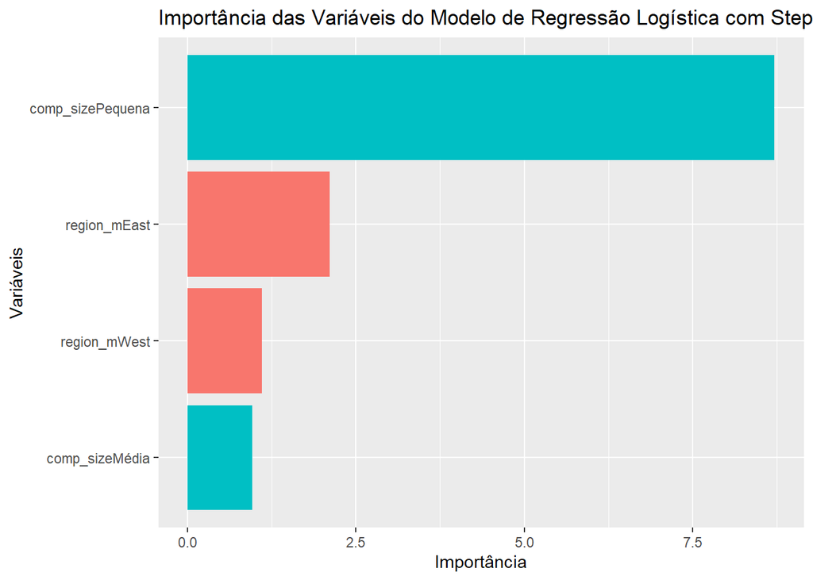

```r
vip(log_stepwise, mapping = aes(fill = Sign)) +
  labs(title = "Importância das Variáveis do Modelo de Regressão Logística com Stepwise", x = "Variáveis", y = "Importância")
```

### 2.4 Modelos sem Outliers

Durante o processo para estimar o modelo de regressão logística, foi feito um alerta que pode ser resultado no número elevado de outliers do dataset, conforme já apontado acima. Assim, vamos estimar o modelo de regressão logítica sem os outliers, utilizando o método de critério IQR (Intervalo Interquartil).

Nesse caso, o primeiro caso é eliminar os outliers. Como os outliers estão concentrados no limite superior da coluna ‘sales’, vamos excluir somente esses valores.

```r
Q1 <- quantile(dados$sales_x, 0.25)
Q3 <- quantile(dados$sales_x, 0.75)
IQR <- Q3 - Q1

ls <- Q3 + 1.5 * IQR

dados_sem_outliers <- subset(dados, sales_x <= ls)
```

A etapa seguinte é criar os datasets de treinamento sem outliers, onde 80% do dataset sem outliers será de treinamento:

```r
idx_sem_outliers <- sample(nrow(dados_sem_outliers), size = .80 * nrow(dados_sem_outliers), replace = FALSE)

treino_sem_outliers <- dados_sem_outliers[idx_sem_outliers,]
```

#### 2.4.1 Regressão Logística sem Outliers

O primeiro modelo a ser estimado sem os outliers é o de regressão logística:

```r
log_sem_outliers <- suppressWarnings({glm(will_close ~ ., data = treino_sem_outliers, family = 'binomial')})
summary(log_sem_outliers)
```

```
##
## Call:
## glm(formula = will_close ~ ., family = "binomial", data = treino_sem_outliers)
##
## Coefficients:
##                     Estimate Std. Error z value Pr(>|z|)
## (Intercept)       -3.059e+00  4.223e-01  -7.245 4.34e-13 ***
## amort              1.105e-07  1.316e-06   0.084 0.933081
## curr_assets        3.572e-08  2.299e-07   0.155 0.876524
## curr_liab         -4.420e-08  1.420e-07  -0.311 0.755507
## extra_exp         -2.829e-04  2.770e-04  -1.021 0.307101
## extra_inc          2.749e-04  2.767e-04   0.994 0.320331
## extra_profit_loss -2.743e-04  2.767e-04  -0.991 0.321523
## fixed_assets       1.903e-08  2.135e-07   0.089 0.928985
## inc_bef_tax       -1.092e-06  8.245e-07  -1.324 0.185361
## intang_assets     -9.955e-08  8.301e-07  -0.120 0.904542
## inventories        3.101e-08  3.091e-07   0.100 0.920088
## liq_assets         1.323e-07  2.300e-07   0.575 0.565193
## material_exp      -6.263e-09  6.216e-08  -0.101 0.919753
## personnel_exp      1.890e-07  3.277e-07   0.577 0.564145
## profit_loss_year  -7.116e-08  7.651e-07  -0.093 0.925894
## sales_x           -8.242e-06  2.416e-06  -3.412 0.000644 ***
## share_eq          -4.430e-08  1.266e-07  -0.350 0.726409
## subscribed_cap    -4.548e-08  1.454e-07  -0.313 0.754461
## tang_assets       -2.236e-08  2.148e-07  -0.104 0.917086
## urban_m2           5.341e-02  1.508e-01   0.354 0.723219
## urban_m3           1.974e-01  1.335e-01   1.478 0.139392
## region_mEast      -3.130e-01  1.417e-01  -2.209 0.027170 *
## region_mWest      -1.787e-01  1.588e-01  -1.125 0.260466
## labor_avg         -6.710e-03  4.467e-02  -0.150 0.880588
## curr_idx_liq      -1.367e-06  6.213e-06  -0.220 0.825825
## comp_age           1.294e-02  7.108e-03   1.820 0.068777 .
## comp_sizeMédia    -7.795e-01  3.123e-01  -2.496 0.012569 *
## comp_sizePequena  -9.088e-02  3.729e-01  -0.244 0.807426
## ---
## Signif. codes:  0 '***' 0.001 '**' 0.01 '*' 0.05 '.' 0.1 ' ' 1
##
## (Dispersion parameter for binomial family taken to be 1)
##
##     Null deviance: 3726.3  on 14644  degrees of freedom
## Residual deviance: 3601.2  on 14617  degrees of freedom
## AIC: 3657.2
##
## Number of Fisher Scoring iterations: 10
```

Agora, vamos aplicar o modelo de previsão nos dados de teste para estimar as probabilidades:

```r
prob_log_sem_outliers <- predict(log_sem_outliers, newdata = teste, type = "response")
```

E armazenar em um tibble os resultados das probabilidades obtidas pela regressão logística e a respectiva classe observada:

```r
desempenho_sem_outliers <- tibble(prob = prob_log_sem_outliers,
                   classes = teste$will_close,
                   metodo = "logística sem outliers")
```

Abaixo, foi plotado o gráfico com a importância de cada variável para esse modelo:

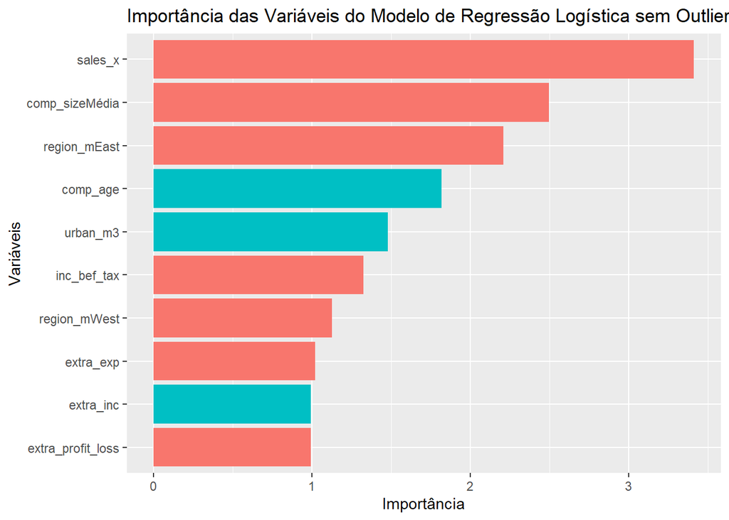

```r
vip(log_sem_outliers, mapping = aes(fill = Sign)) +
  labs(title = "Importância das Variáveis do Modelo de Regressão Logística sem Outliers", x = "Variáveis", y = "Importância")
```

#### 2.4.2 Modelo Ridge sem Outliers

O próximo modelo a ser estimado sem os outliers é o Ridge. Assim como foi feito no modelo ridge anterior, deverão ser preparadados os datasets de treinamento e teste para aplicação da função do pacote glmnet.

```r
X_treino_sem_outliers <- model.matrix(will_close ~ ., dados_sem_outliers)[idx_sem_outliers,-1]
y_treino_sem_outliers <- dados_sem_outliers$will_close[idx_sem_outliers]
```

Abaixo, foi criado o modelo Ridge e plotando o gráfico com os lambdas variando até 500:

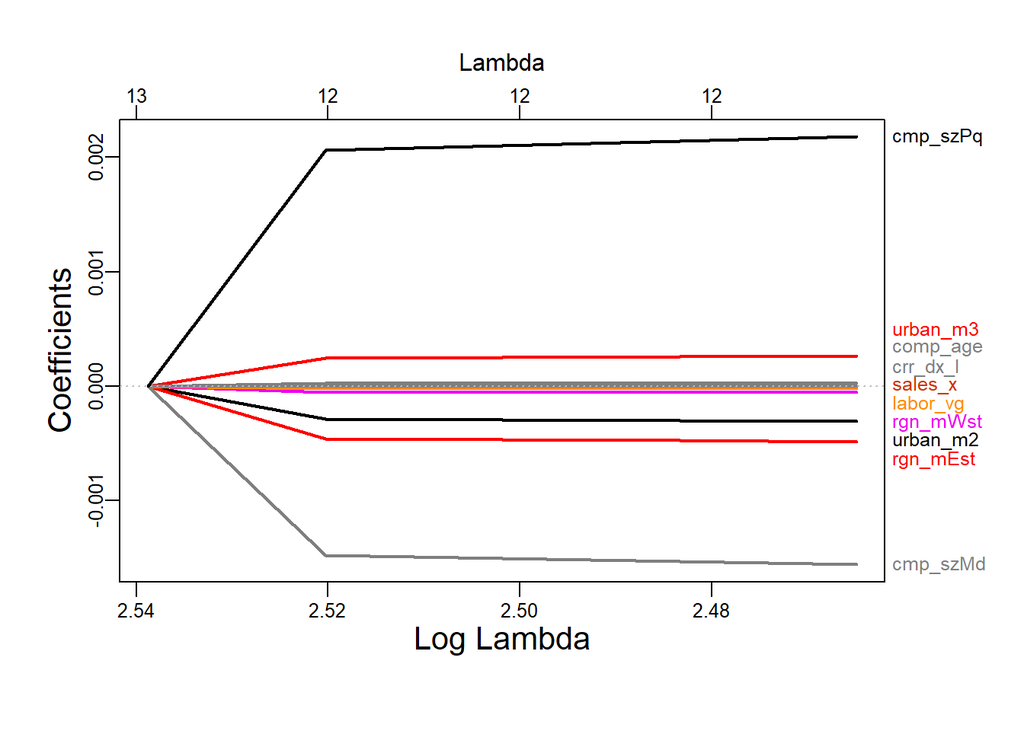

```r
ridge_sem_outliers <- glmnet(X_treino_sem_outliers, y_treino_sem_outliers,  alpha = 0,
                             nlambda = 500, family = "binomial")
plot_glmnet(ridge_sem_outliers, lwd = 2, cex.lab = 1.3)
```

A seguir, vamos fazer a validação cruzada do modelo:

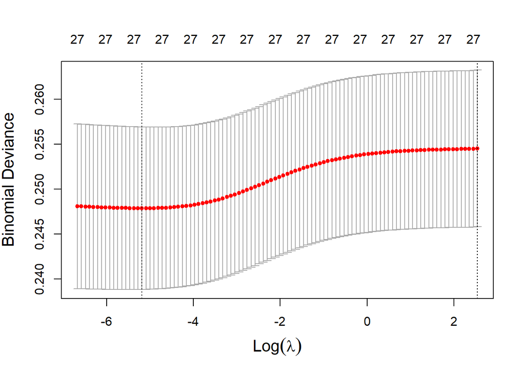

```r
cv_ridge_sem_outliers <- cv.glmnet(X_treino_sem_outliers, y_treino_sem_outliers, alpha = 0, family = "binomial")
plot(cv_ridge_sem_outliers, cex.lab = 1.3)
```

Vamos aplicar o modelo de previsão com base no melhor lambda (menor erro), estimando as probabilidades a partir da base de teste:

```r
prob_ridge_sem_outliers <- predict(ridge_sem_outliers, newx = X_teste,
                      s = cv_ridge_sem_outliers$lambda.min, type = "response")
```

E armazenar em um tibble os resultados das probabilidades obtidas pelo modelo Ridge e a respectiva classe observada:

```r
desempenho_sem_outliers <- desempenho_sem_outliers %>%
  bind_rows(tibble(prob = as.numeric(prob_ridge_sem_outliers),
                   classes = y_teste,
                   metodo = "ridge sem outliers"))
```

Abaixo, plotamos o gráfico com a importância de cada variável para esse modelo Rigde:

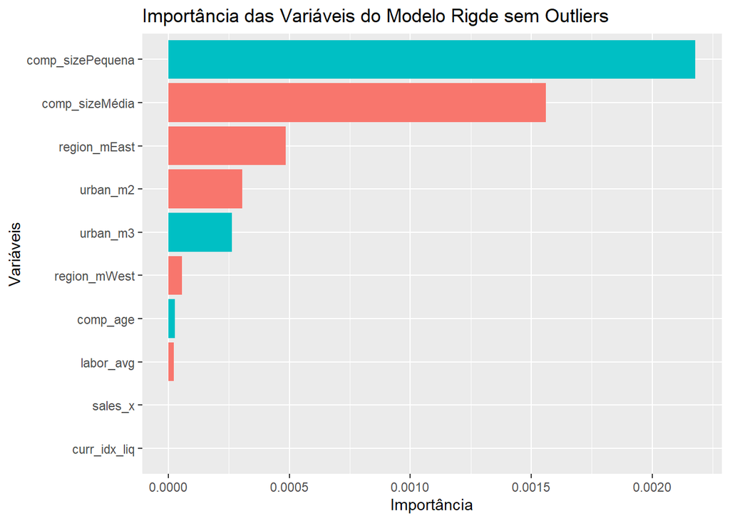

```r
vip(ridge_sem_outliers, mapping = aes(fill = Sign)) +
  labs(title = "Importância das Variáveis do Modelo Rigde sem Outliers", x = "Variáveis", y = "Importância")
```

#### 2.4.3 Regressão LASSO sem Outliers

O modelo seguinte a ser criado sem outliers é o LASSO. Assim como no modelo Ridge, foi criado o modelo LASSO e plotado o gráfico com os lambdas variando até 500:

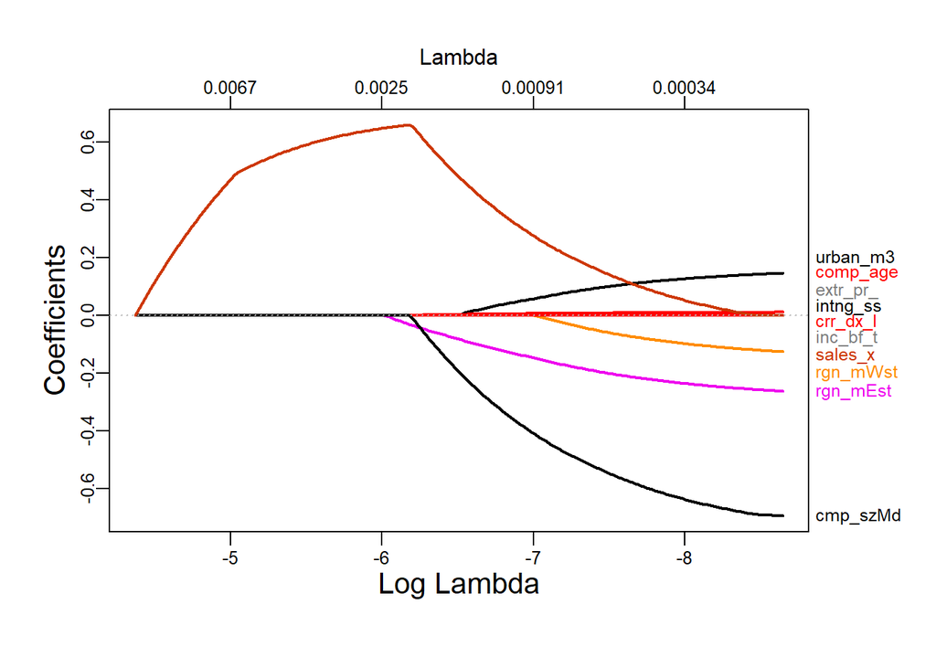

```r
lasso_sem_outliers <- glmnet(X_treino_sem_outliers, y_treino_sem_outliers,
                             alpha = 1, nlambda = 500, family = "binomial")
plot_glmnet(lasso_sem_outliers, lwd = 2, cex.lab = 1.3)
```

O próximo passo é fazer a validação cruzada do modelo:

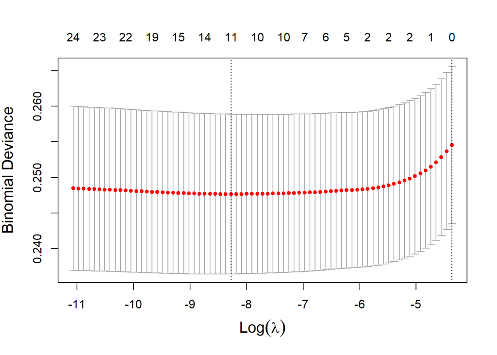

```r
cv_lasso_sem_outliers <- cv.glmnet(X_treino_sem_outliers, y_treino_sem_outliers, alpha = 1, family = "binomial")
plot(cv_lasso_sem_outliers, cex.lab = 1.3)
```

Agora, será aplicado o modelo de previsão com base no melhor lambda (menor erro), estimando as probabilidades a partir da base de teste:

```r
prob_lasso_sem_outliers <- predict(lasso_sem_outliers, newx = X_teste,
                                   s = cv_lasso_sem_outliers$lambda.min, type = "response")
```

E armazenado em um tibble os resultados das probabilidades obtidas pelo modelo Lasso e a respectiva classe observada:

```r
desempenho_sem_outliers <- desempenho_sem_outliers %>%
  bind_rows(tibble(prob = as.numeric(prob_lasso_sem_outliers),
                   classes = y_teste,
                   metodo = "lasso sem outliers"))
```

Abaixo, foi plotado o gráfico com a importância de cada variável para esse modelo:

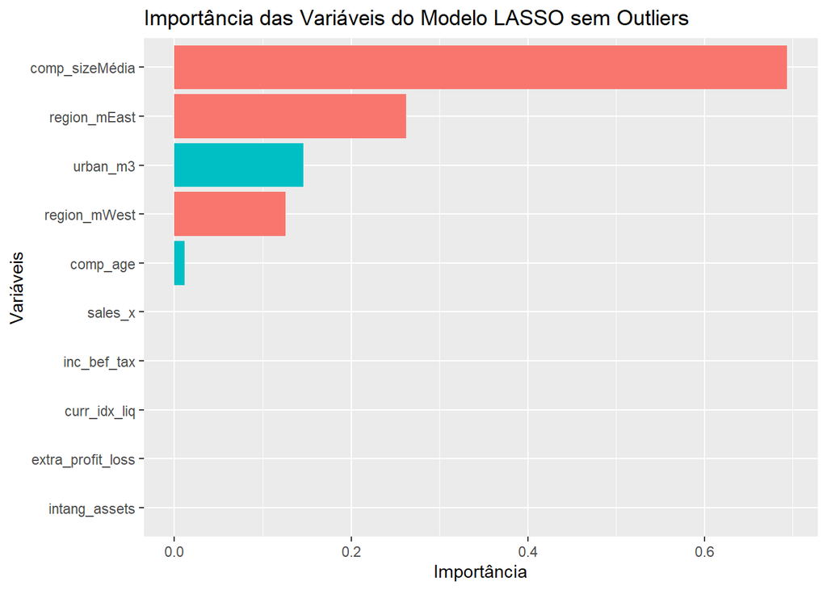

```r
vip(lasso_sem_outliers, mapping = aes(fill = Sign)) +
  labs(title = "Importância das Variáveis do Modelo LASSO sem Outliers", x = "Variáveis", y = "Importância")
```

#### 2.4.4 Floresta Aleatória sem Outliers

O próximo modelo sem outliers que será criado e testado é o de floresta aleatória com 500 árvores e com todas as variáveis:

```r
rf_sem_outliers <- ranger(will_close ~ ., probability = TRUE, data = treino_sem_outliers)
```

Para essa floresta aleatória com 500 árvores e com todas as variáveis, vamos fazer a previsão a partir dos dados de teste:

```r
prob_rf_sem_outliers <- predict(rf_sem_outliers, teste)$predictions[,2]
```

E armazenando em um tibble os resultados das probabilidades obtidas pelo modelo de floresta aleatória e a respectiva classe observada:

```r
desempenho_sem_outliers <- desempenho_sem_outliers %>%
  bind_rows(tibble(prob = prob_rf_sem_outliers,
                   classes = teste$will_close,
                   metodo = "floresta aleatória sem outliers"))
```

Abaixo, plotamos o gráfico com a importância de cada variável para esse modelo de floresta aleatória:

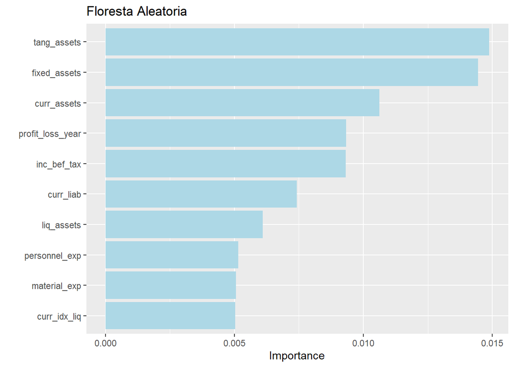

```r
vip(ranger(will_close ~ ., probability = TRUE, importance = "permutation", data = dados_sem_outliers), aesthetics = list(fill = "lightblue")) + labs(title = "Floresta Aleatoria")
```

Agora, vamos iterar para testar o número de árvores de 1 a 500, bem como o número de variáveis por split, plotar o resultado dessa iteração:

```r
result_arvores_sem_outliers <- crossing(mtry = c(2, 4, 8, 12, 16, 20, 23), #número de variáveis por split a ser testados
                       n_arvores = c(1:10, seq(10, 500, 10)))

itera_sem_outliers <- function(mtry, n_arvores) {
  rf_itera_sem_outliers <- ranger(will_close ~ ., probability = TRUE, num.trees = n_arvores, mtry = mtry, data = treino_sem_outliers)
  return(rf_itera_sem_outliers$prediction.error)
}
result_arvores_sem_outliers <- result_arvores_sem_outliers %>%
  mutate(erro = map2_dbl(mtry, n_arvores, itera_sem_outliers))
head(result_arvores_sem_outliers)
```

```
## # A tibble: 6 × 3
##    mtry n_arvores   erro
##   <dbl>     <dbl>  <dbl>
## 1     2         1 0.0483
## 2     2         2 0.0422
## 3     2         3 0.0410
## 4     2         4 0.0408
## 5     2         5 0.0378
## 6     2         6 0.0356
```

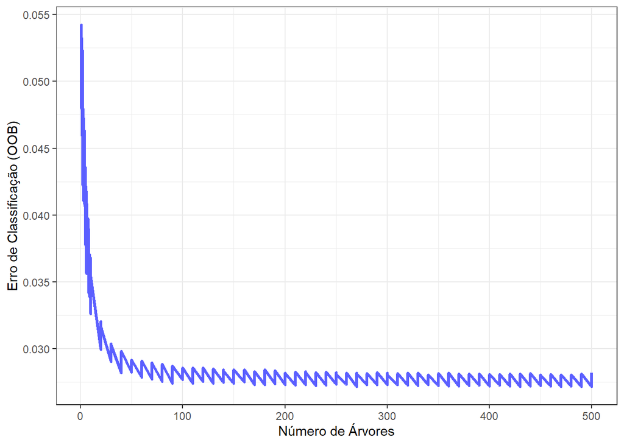

```r
result_arvores_sem_outliers %>% ggplot(aes(n_arvores, erro)) +
 geom_line(color = "#5B5FFF", size = 1.2) +
 labs(x = "Número de Árvores", y = "Erro de Classificação (OOB)") +
 theme_bw()
```

A partir da iteração acima, vamos obter os dados da floresta ótima (número de árvores e número de variáveis por split) com o menor erro:

```r
floresta_otima_sem_outliers <- result_arvores_sem_outliers %>% as_tibble() %>% filter(erro== min(erro))#Obtendo dados da floresta ótima
mtry_otimo_sem_outliers <- floresta_otima_sem_outliers$mtry #numero de arvores para floresta otima
n_arvores_otimo_sem_outliers <- floresta_otima_sem_outliers$n_arvores # variaveis por split
```

E criar o modelo de floresta aleatória ótima:

```r
rf_otima_sem_outliers <- ranger(will_close ~ ., probability = TRUE, num.trees = n_arvores_otimo_sem_outliers,
                   mtry = mtry_otimo_sem_outliers, data = treino_sem_outliers)
```

Para essa floresta aleatória ótima, vamos fazer a previsão a partir dos dados de teste:

```r
prob_rf_otima_sem_outliers <- predict(rf_otima_sem_outliers, teste)$predictions[,2]
```

```r
desempenho_sem_outliers <- desempenho_sem_outliers %>%
  bind_rows(tibble(prob = prob_rf_otima_sem_outliers,
                   classes = teste$will_close,
                   metodo = "floresta aleatória ótima sem outliers"))
```

Abaixo, plotamos o gráfico com a importância de cada variável para esse modelo de floresta aleatória otimizada:

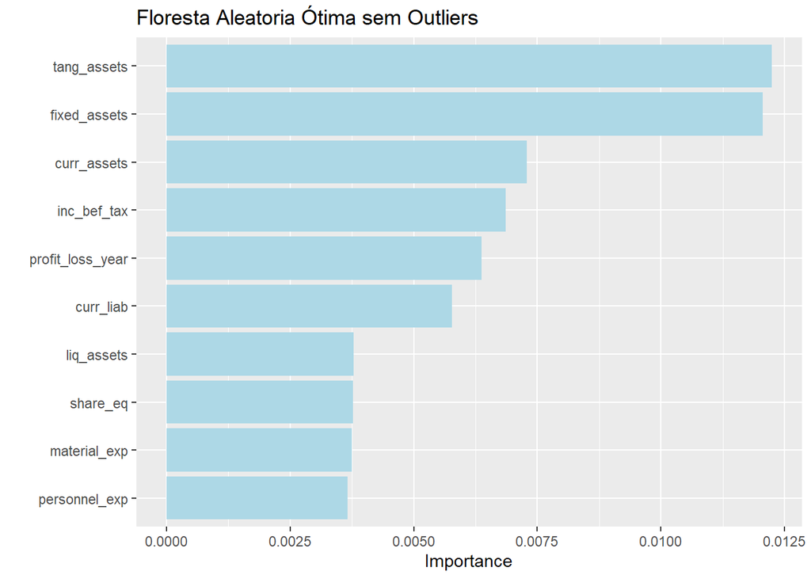

```r
vip(ranger(will_close ~ ., probability = TRUE, importance = "permutation", num.trees = n_arvores_otimo_sem_outliers, mtry = mtry_otimo_sem_outliers, data = treino_sem_outliers),
    aesthetics = list(fill = "lightblue")) + labs(title = "Floresta Aleatoria Ótima sem Outliers")
```

#### 2.4.5 Boosting sem outliers

Agora, será criado e testado nesse ciclo de modelagem é o Boosting sem os outliers com 1000 árvores, taxa de aprendizagem de 0,05, 4 variáveis por split e um número de folds de 5:

```r
(fit_bst_sem_outliers <- gbm(will_close ~ ., distribution = "bernoulli", n.trees = 1000,
                interaction.depth = 4, shrinkage = 0.05, data = treino_sem_outliers))
```

```
## gbm(formula = will_close ~ ., distribution = "bernoulli", data = treino_sem_outliers,
##     n.trees = 1000, interaction.depth = 4, shrinkage = 0.05)
## A gradient boosted model with bernoulli loss function.
## 1000 iterations were performed.
## There were 24 predictors of which 24 had non-zero influence.
```

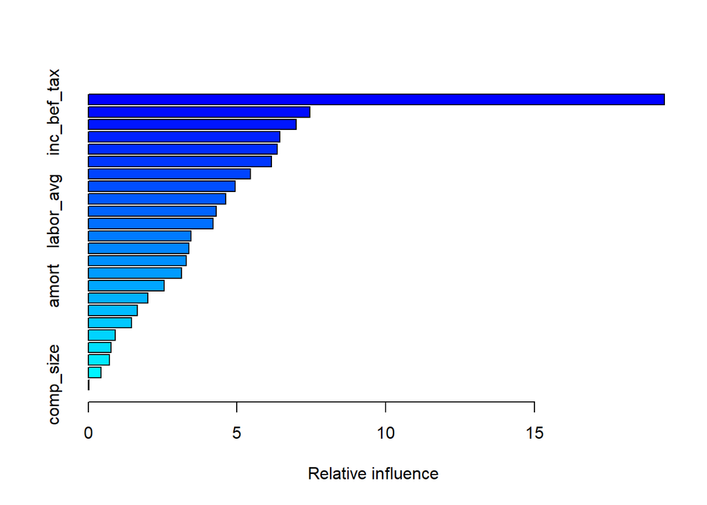

```
##                                 var     rel.inf
## sales_x                     sales_x 19.37442109
## inc_bef_tax             inc_bef_tax  7.44716806
## curr_idx_liq           curr_idx_liq  6.98446523
## liq_assets               liq_assets  6.43771684
## share_eq                   share_eq  6.35424414
## curr_assets             curr_assets  6.16685787
## profit_loss_year   profit_loss_year  5.45967371
## curr_liab                 curr_liab  4.94356397
## personnel_exp         personnel_exp  4.61252142
## labor_avg                 labor_avg  4.30295966
## material_exp           material_exp  4.20101425
## inventories             inventories  3.45096435
## subscribed_cap       subscribed_cap  3.37930946
## comp_age                   comp_age  3.30160865
## fixed_assets           fixed_assets  3.12543704
## amort                         amort  2.54254017
## tang_assets             tang_assets  2.00158265
## urban_m                     urban_m  1.64522639
## extra_inc                 extra_inc  1.44843424
## intang_assets         intang_assets  0.90047169
## region_m                   region_m  0.76035645
## extra_profit_loss extra_profit_loss  0.71422735
## extra_exp                 extra_exp  0.41981732
## comp_size                 comp_size  0.02541799
```

```r
summary(fit_bst_sem_outliers)
```

O passo seguinte é fazer a validação cruzadas do modelo para obter o número de árvores ótimo:

```r
fit_cv_sem_outliers <- gbm(will_close ~ ., data = treino_sem_outliers, cv.folds = 5, n.trees = 1000,
              interaction.depth = 4, distribution = "bernoulli", shrinkage = 0.05)

num_arv_boost_sem_outliers <- gbm.perf(fit_cv_sem_outliers, method = "cv") #obtendo a árvore ótima
```

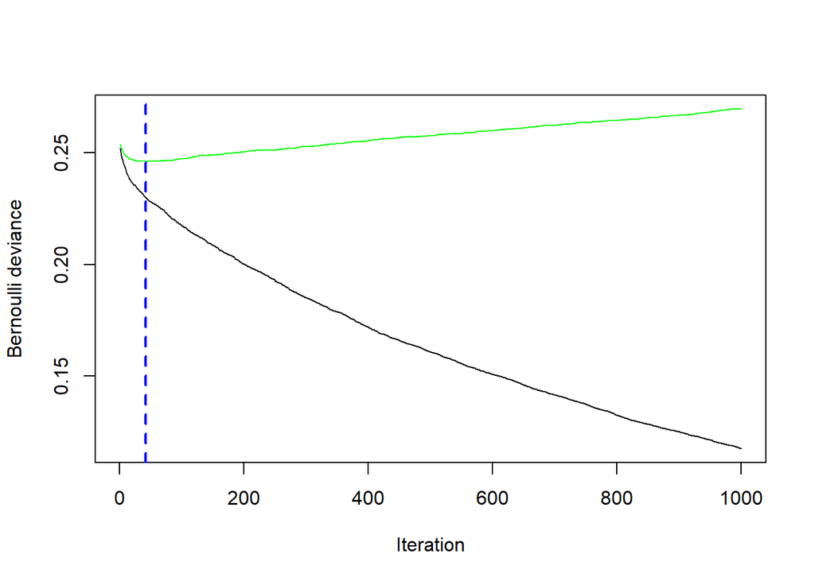

Aplicando o modelo de previsão com base na melhor quantidade de árvores (menor erro) e estimando as probabilidades a partir da base de teste, temos:

```r
prob_gbm_sem_outliers <- predict(fit_cv_sem_outliers, teste, n.trees = num_arv_boost_sem_outliers, type = "response")
```

```r
desempenho_sem_outliers <- desempenho_sem_outliers %>%
  bind_rows(tibble(prob = prob_gbm_sem_outliers,
                   classes = teste$will_close,
                   metodo = "boosting sem outliers"))
```

### 2.5 Resultados dos Modelos Estimados

#### 2.5.1 Modelos com Outliers

Inicialmente, vamos plotar a curva ROC para cada um dos modelos:

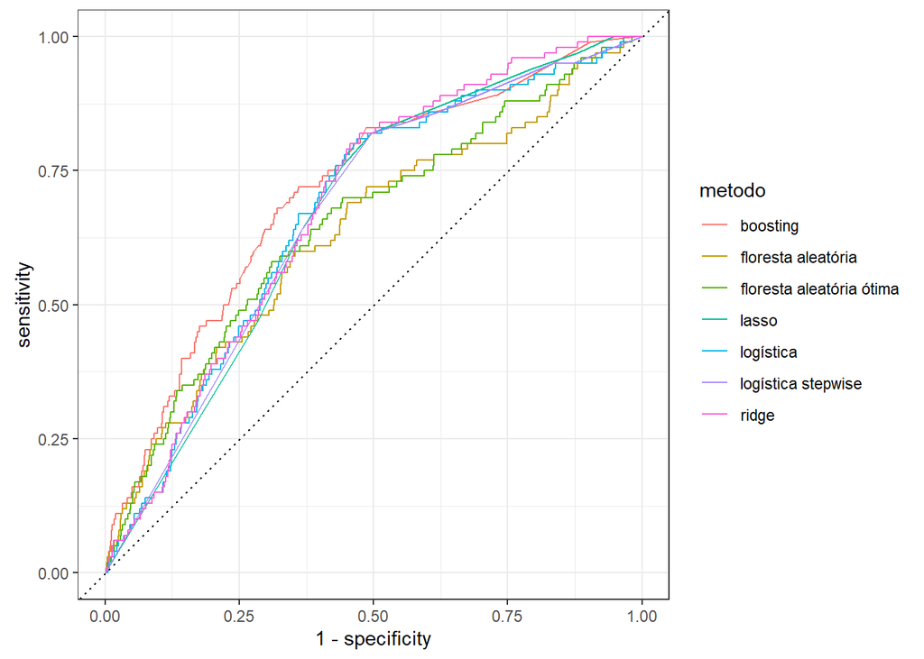

```r
desempenho %>%
  mutate(classes = factor(classes)) %>%
  group_by(metodo) %>%
  roc_curve(classes, prob, event_level = "second") %>%
  autoplot()
```

E calcular o AUC, a métrica de desempenho, para cada modelo estimado:

```r
desempenho %>%
  mutate(classes = factor(classes)) %>%
  group_by(metodo) %>%
  roc_auc(classes, prob, event_level = "second") %>%
  arrange(desc(.estimate))
```

```
## # A tibble: 7 × 4
##   metodo                   .metric .estimator .estimate
##   <chr>                    <chr>   <chr>          <dbl>
## 1 boosting                 roc_auc binary         0.713
## 2 ridge                    roc_auc binary         0.684
## 3 logística                roc_auc binary         0.674
## 4 lasso                    roc_auc binary         0.671
## 5 logística stepwise       roc_auc binary         0.670
## 6 floresta aleatória ótima roc_auc binary         0.651
## 7 floresta aleatória       roc_auc binary         0.633
```

#### 2.5.2 Modelos sem Outliers

Agora, vamos plotar a curva ROC para cada um dos modelos que foram estimados sem os outliers no dataset:

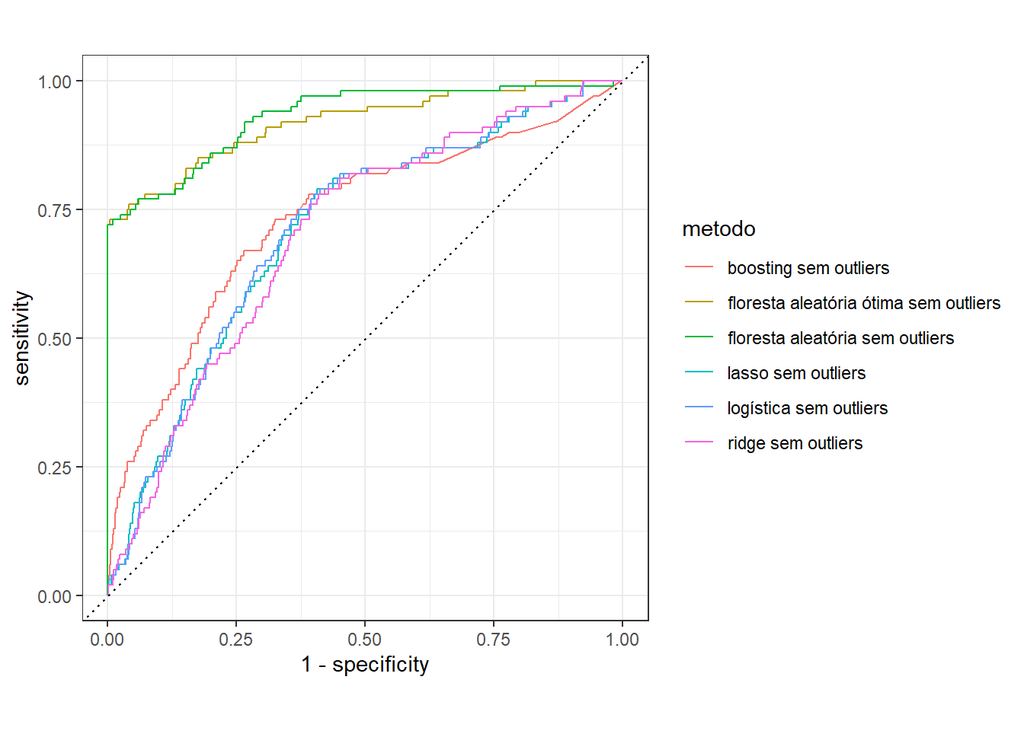

```r
desempenho_sem_outliers %>%
  mutate(classes = factor(classes)) %>%
  group_by(metodo) %>%
  roc_curve(classes, prob, event_level = "second") %>%
  autoplot()
```

E calcular AUC para esses modelos:

```r
desempenho_sem_outliers %>%
  mutate(classes = factor(classes)) %>%
  group_by(metodo) %>%
  roc_auc(classes, prob, event_level = "second") %>%
  arrange(desc(.estimate))
```

```
## # A tibble: 6 × 4
##   metodo                                .metric .estimator .estimate
##   <chr>                                 <chr>   <chr>          <dbl>
## 1 floresta aleatória sem outliers       roc_auc binary         0.930
## 2 floresta aleatória ótima sem outliers roc_auc binary         0.919
## 3 boosting sem outliers                 roc_auc binary         0.732
## 4 logística sem outliers                roc_auc binary         0.711
## 5 lasso sem outliers                    roc_auc binary         0.710
## 6 ridge sem outliers                    roc_auc binary         0.702
```

## 3.Conclusão

A partir de dados contábeis e financeiros da empresa em um determinado ano com todos outliers, os modelos estimados tiveram o seguinte resultado:

- O modelo de boosting foi que obteve o melhor desempenho. NO entanto, não foi muito superior aos demais, que apresentaram resultados de performance próximos;
- A importância das variáveis preditoras em cada modelo variou: enquanto nos modelos de regressão logística e de regularização os pesos das variáveis categóricas foram mais relevantes; nos modelos de floresta e boosting, as variáveis númericas foram mais relevantes;
- importância das variáveis no modelo de boosting corrobora com a intuição prévia, colocando variáveis financeiras como vendas (sales_x), patrimônio líquido (share_eq) e capital circulante líquido (curr_idx_liq) como mais relevantes para o modelo;
- Aplicar o método de seleção de subconjuntos não melhora o desempenho do modelo de regressão logística. Além disso, houve uma redução significativa do número de varáveis selecionadas em relação ao modelo de regressão logísitica com todas as variáveis, restando apenas 4 categóricas.

Apesar de alguns modelos estimados, sem a presença dos outliers no dataset, possuírem melhor desempenho, cabe ressaltar que não necessariamente podem ser melhores, uma vez que retirou-se informações que são características da população (ter empresas com faturamento alto).